# 1 Análisis exploratorio de variables clínicas y mutacionales asociadas a la clasificación histológica (LGG vs. GBM)

El presente análisis exploratorio busca caracterizar las diferencias clínicas y moleculares entre los pacientes con Gliomas de Bajo Grado (LGG) y Glioblastoma Multiforme (GBM), con especial atención a las variables que puedan estar asociadas con el grado histológico del tumor. Para ello, se examinan tanto características clínicas como patrones de mutación en genes seleccionados, con el propósito de identificar comportamientos relevantes dentro de los datos antes de avanzar hacia las etapas de preprocesamiento y modelado.

El análisis parte del conjunto de datos Glioma Grading Clinical and Mutation Features, construido a partir de información de los proyectos TCGA-LGG y TCGA-GBM de *The Cancer Genome Atlas*. El conjunto contiene registros de pacientes y variables clínicas y genéticas, teniendo como variable objetivo la clasificación binaria del grado tumoral entre LGG y GBM.

A lo largo de esta sección se estudiará la estructura general de los datos, la distribución de las variables, sus características clínicas y mutacionales y su comportamiento en función del grado tumoral. Estos resultados permitirán establecer una primera comprensión del conjunto de datos y servirán como base para definir posteriormente las transformaciones y variables utilizadas en el desarrollo del modelo predictivo.

## 1.1 Carga de datos y Estructura

### 1.1.1 Librerías

```r
# Librerías
## Manipulación de datos
library(tidyverse)   # dplyr, tidyr, purrr, ggplot2, stringr
library(scales)      # formato de ejes y porcentajes

## Tablas
library(knitr)
library(kableExtra)

## Visualización
library(patchwork)   # composición de gráficos en grilla

# Configuración visual
PALETTE_GRADE <- c("0" = "#2E86AB", "1" = "#C1443C")

theme_set(
  theme_minimal(base_size = 12) +
    theme(
      panel.grid.minor = element_blank(),
      plot.title       = element_text(hjust = 0.5)
    )
)

# Convierte un ggplot en una imagen PNG embebida (base64), para poder
# insertarlo dentro de bloques HTML como en el notebook de Python.
ggplot_a_base64 <- function(p, width, height, dpi = 120) {
  archivo <- tempfile(fileext = ".png")
  ggsave(archivo, p, width = width, height = height, dpi = dpi, bg = "white")
  knitr::image_uri(archivo)
}

# Asimetría y curtosis (exceso) con los mismos estimadores que pandas
# (Series.skew() y Series.kurt()).
asimetria <- function(x) {
  n <- length(x); m <- mean(x)
  g1 <- mean((x - m)^3) / mean((x - m)^2)^1.5
  g1 * sqrt(n * (n - 1)) / (n - 2)
}

curtosis <- function(x) {
  n <- length(x); m <- mean(x)
  g2 <- mean((x - m)^4) / mean((x - m)^2)^2 - 3
  ((n + 1) * g2 + 6) * (n - 1) / ((n - 2) * (n - 3))
}
```

### 1.1.2 Dataset

El conjunto de datos utilizado para el análisis es `TCGA_InfoWithGrade.csv`, correspondiente a una versión preprocesada de los datos relacionados con gliomas del proyecto The Cancer Genome Atlas (TCGA).

```r
df_mutations <- read_csv("dataset/TCGA_InfoWithGrade.csv", show_col_types = FALSE)

kable(head(df_mutations)) |>
  kable_styling(bootstrap_options = c("striped", "hover", "condensed"),
                full_width = TRUE, font_size = 12) |>
  scroll_box(width = "100%")
```

| Grade | Gender | Age_at_diagnosis | Race | IDH1 | TP53 | ATRX | PTEN | EGFR | CIC | MUC16 | PIK3CA | NF1 | PIK3R1 | FUBP1 | RB1 | NOTCH1 | BCOR | CSMD3 | SMARCA4 | GRIN2A | IDH2 | FAT4 | PDGFRA |
| --- | --- | --- | --- | --- | --- | --- | --- | --- | --- | --- | --- | --- | --- | --- | --- | --- | --- | --- | --- | --- | --- | --- | --- |
| 0 | 0 | 51.30 | 0 | 1 | 0 | 0 | 0 | 0 | 0 | 0 | 1 | 0 | 0 | 1 | 0 | 0 | 0 | 0 | 0 | 0 | 0 | 0 | 0 |
| 0 | 0 | 38.72 | 0 | 1 | 0 | 0 | 0 | 0 | 1 | 0 | 0 | 0 | 0 | 0 | 0 | 0 | 0 | 0 | 0 | 0 | 0 | 0 | 0 |
| 0 | 0 | 35.17 | 0 | 1 | 1 | 1 | 0 | 0 | 0 | 0 | 0 | 0 | 0 | 0 | 0 | 0 | 0 | 0 | 0 | 0 | 0 | 0 | 0 |
| 0 | 1 | 32.78 | 0 | 1 | 1 | 1 | 0 | 0 | 0 | 1 | 0 | 0 | 1 | 0 | 0 | 0 | 0 | 0 | 0 | 0 | 0 | 1 | 0 |
| 0 | 0 | 31.51 | 0 | 1 | 1 | 1 | 0 | 0 | 0 | 0 | 0 | 0 | 0 | 0 | 0 | 0 | 0 | 0 | 0 | 0 | 0 | 0 | 0 |
| 0 | 1 | 33.21 | 0 | 1 | 0 | 1 | 0 | 0 | 0 | 0 | 0 | 0 | 0 | 0 | 0 | 0 | 0 | 0 | 0 | 0 | 0 | 0 | 0 |

```r
kable(tail(df_mutations)) |>
  kable_styling(bootstrap_options = c("striped", "hover", "condensed"),
                full_width = TRUE, font_size = 12) |>
  scroll_box(width = "100%")
```

| Grade | Gender | Age_at_diagnosis | Race | IDH1 | TP53 | ATRX | PTEN | EGFR | CIC | MUC16 | PIK3CA | NF1 | PIK3R1 | FUBP1 | RB1 | NOTCH1 | BCOR | CSMD3 | SMARCA4 | GRIN2A | IDH2 | FAT4 | PDGFRA |
| --- | --- | --- | --- | --- | --- | --- | --- | --- | --- | --- | --- | --- | --- | --- | --- | --- | --- | --- | --- | --- | --- | --- | --- |
| 1 | 0 | 56.31 | 0 | 0 | 0 | 0 | 0 | 0 | 0 | 0 | 0 | 0 | 0 | 0 | 0 | 0 | 0 | 0 | 0 | 0 | 0 | 0 | 0 |
| 1 | 1 | 77.89 | 0 | 0 | 0 | 0 | 1 | 0 | 0 | 0 | 0 | 0 | 0 | 0 | 0 | 0 | 0 | 0 | 0 | 0 | 0 | 0 | 0 |
| 1 | 0 | 85.18 | 0 | 0 | 1 | 0 | 1 | 0 | 0 | 0 | 0 | 0 | 0 | 0 | 0 | 0 | 0 | 0 | 0 | 0 | 0 | 0 | 0 |
| 1 | 1 | 77.49 | 0 | 0 | 1 | 0 | 1 | 0 | 0 | 0 | 0 | 0 | 0 | 0 | 0 | 0 | 0 | 0 | 0 | 0 | 0 | 0 | 0 |
| 1 | 0 | 63.33 | 0 | 0 | 1 | 0 | 0 | 0 | 0 | 1 | 1 | 0 | 0 | 0 | 1 | 0 | 0 | 0 | 0 | 0 | 0 | 0 | 0 |
| 1 | 0 | 76.61 | 1 | 0 | 0 | 0 | 0 | 0 | 0 | 0 | 0 | 0 | 0 | 0 | 0 | 0 | 0 | 0 | 0 | 0 | 0 | 0 | 0 |

### 1.1.3 Estructura

```r
cat(sprintf("Dimensiones del dataset: %d pacientes x %d variables\n",
            nrow(df_mutations), ncol(df_mutations)))
```

```
## Dimensiones del dataset: 839 pacientes x 24 variables
```

```r
cat(sprintf("Registros duplicados: %d\n", sum(duplicated(df_mutations))))
```

```
## Registros duplicados: 1
```

```r
cat(sprintf("Valores faltantes: %d\n", sum(is.na(df_mutations))))
```

```
## Valores faltantes: 0
```

```r
info_df <- tibble(
  Columna            = names(df_mutations),
  `Tipo de dato`     = map_chr(df_mutations, ~ class(.x)[1]),
  `Valores no nulos` = map_int(df_mutations, ~ sum(!is.na(.x))),
  `Valores nulos`    = map_int(df_mutations, ~ sum(is.na(.x))),
  `Valores únicos`   = map_int(df_mutations, ~ n_distinct(.x))
)

kable(info_df, caption = "Resumen Estructural del Dataset") |>
  kable_styling(bootstrap_options = c("striped", "condensed"), full_width = FALSE) |>
  column_spec(1, bold = TRUE) |>
  column_spec(5, color = "white",
              background = spec_color(info_df$`Valores únicos`, end = 0.8,
                                      option = "D", direction = -1))
```

Table 1.1: Table 1.2: Resumen Estructural del Dataset

| Columna | Tipo de dato | Valores no nulos | Valores nulos | Valores únicos |
| --- | --- | --- | --- | --- |
| Grade | numeric | 839 | 0 | 2 |
| Gender | numeric | 839 | 0 | 2 |
| Age_at_diagnosis | numeric | 839 | 0 | 766 |
| Race | numeric | 839 | 0 | 4 |
| IDH1 | numeric | 839 | 0 | 2 |
| TP53 | numeric | 839 | 0 | 2 |
| ATRX | numeric | 839 | 0 | 2 |
| PTEN | numeric | 839 | 0 | 2 |
| EGFR | numeric | 839 | 0 | 2 |
| CIC | numeric | 839 | 0 | 2 |
| MUC16 | numeric | 839 | 0 | 2 |
| PIK3CA | numeric | 839 | 0 | 2 |
| NF1 | numeric | 839 | 0 | 2 |
| PIK3R1 | numeric | 839 | 0 | 2 |
| FUBP1 | numeric | 839 | 0 | 2 |
| RB1 | numeric | 839 | 0 | 2 |
| NOTCH1 | numeric | 839 | 0 | 2 |
| BCOR | numeric | 839 | 0 | 2 |
| CSMD3 | numeric | 839 | 0 | 2 |
| SMARCA4 | numeric | 839 | 0 | 2 |
| GRIN2A | numeric | 839 | 0 | 2 |
| IDH2 | numeric | 839 | 0 | 2 |
| FAT4 | numeric | 839 | 0 | 2 |
| PDGFRA | numeric | 839 | 0 | 2 |

```r
columnas_categoricas <- setdiff(names(df_mutations), "Age_at_diagnosis")

df_mutations <- df_mutations |>
  mutate(across(all_of(columnas_categoricas), as.factor))

kable(t(map_chr(df_mutations, ~ class(.x)[1])), row.names = FALSE) |>
  kable_styling(bootstrap_options = c("striped", "condensed"), font_size = 11) |>
  scroll_box(width = "100%")
```

| Grade | Gender | Age_at_diagnosis | Race | IDH1 | TP53 | ATRX | PTEN | EGFR | CIC | MUC16 | PIK3CA | NF1 | PIK3R1 | FUBP1 | RB1 | NOTCH1 | BCOR | CSMD3 | SMARCA4 | GRIN2A | IDH2 | FAT4 | PDGFRA |
| --- | --- | --- | --- | --- | --- | --- | --- | --- | --- | --- | --- | --- | --- | --- | --- | --- | --- | --- | --- | --- | --- | --- | --- |
| factor | factor | numeric | factor | factor | factor | factor | factor | factor | factor | factor | factor | factor | factor | factor | factor | factor | factor | factor | factor | factor | factor | factor | factor |

El conjunto de datos presenta una estructura limpia y estructurada, compuesta por 839 registros (pacientes) y 24 variables, sin presencia de valores nulos o faltantes. Aunque se presente un registro duplicado, este representa a dos pacientes distintos que casualmente comparten el mismo fenotipo y perfil genético, ya que su ID es distinto en el dataset original (`TCGA_GBM_LGG_Mutations_all`).

Las variables binarias, originalmente codificadas mediante valores enteros `0` y `1`, fueron transformadas al tipo categórico (`factor`) para representar adecuadamente su naturaleza y facilitar su análisis exploratorio.

## 1.2 Contexto de los datos

| Categoría | Variables | Codificación |
| --- | --- | --- |
| **Variable objetivo** | `Grade` | 0 = LGG (glioma de bajo grado), 1 = GBM (glioblastoma) |
| **Demográficas** | `Gender`, `Age_at_diagnosis`, `Race` | `Gender`: 0/1; `Race`: 0–3 (categorías étnicas codificadas); `Age`: continua (años) |
| **Mutacionales** | 20 genes (`IDH1`, `TP53`, `ATRX`, `PTEN`, `EGFR`, `CIC`, `MUC16`, `PIK3CA`, `NF1`, `PIK3R1`, `FUBP1`, `RB1`, `NOTCH1`, `BCOR`, `CSMD3`, `SMARCA4`, `GRIN2A`, `IDH2`, `FAT4`, `PDGFRA`) | 0 = no mutado, 1 = mutado |

### 1.2.1 Variable Objetivo

- **`Grade`**: Indica el grado del glioma (0 = `LGG`, 1 = `GBM`). Esta variable distingue entre los dos grupos principales del conjunto de datos: Glioma de Bajo Grado (*Low-Grade Glioma*) y Glioblastoma Multiforme (*Glioblastoma Multiforme*).

### 1.2.2 Variables Clínicas

Proporcionan información sobre las características demográficas de los pacientes:

- **`Gender`**: Género del paciente (0 = masculino, 1 = femenino).
- **`Age_at_diagnosis`**: Edad del paciente al momento del diagnóstico expresada en años (numérica continua). La parte decimal incorpora la información exacta de los días transcurridos.
- **`Race`**: Raza reportada del paciente codificada del 0 al 3 (0 = *White*, 1 = *Black or African American*, 2 = *Asian*, 3 = *American Indian or Alaska Native*).

### 1.2.3 Variables genéticas

El conjunto de datos también contiene variables correspondientes a diferentes genes. Estas variables están codificadas de forma binaria, indicando con un valor de 1 la presencia de una mutación en el gen correspondiente, y con un 0 la condición de gen salvaje / no mutado (*wildtype*):

- **`IDH1`**: Codifica una enzima involucrada en el metabolismo celular.
- **`TP53`**: Gen supresor tumoral que participa en el control del ciclo celular y en la respuesta al daño del ADN. Sus alteraciones favorecen la proliferación tumoral.
- **`ATRX`**: Participa en el mantenimiento de la estructura de la cromatina y en la estabilidad del genoma.
- **`PTEN`**: Gen supresor tumoral que regula vías relacionadas con el crecimiento y la supervivencia celular.
- **`EGFR`**: Codifica un receptor involucrado en señales de crecimiento y proliferación celular.
- **`CIC`**: Participa en la regulación de la expresión de otros genes y en procesos relacionados con el desarrollo celular.
- **`MUC16`**: Codifica una proteína de gran tamaño asociada a la superficie celular.
- **`PIK3CA`**: Participa en la vía de señalización PI3K/AKT, relacionada con crecimiento, supervivencia y proliferación celular.
- **`NF1`**: Actúa como regulador negativo de señales relacionadas con el crecimiento celular. Sus alteraciones pueden contribuir a la proliferación tumoral.
- **`PIK3R1`**: Codifica una subunidad reguladora de la vía PI3K, que interviene en procesos de crecimiento y supervivencia celular.
- **`FUBP1`**: Participa en la regulación de la expresión génica y del crecimiento celular.
- **`RB1`**: Gen supresor tumoral que participa en el control del ciclo celular y regula la progresión de las células hacia la división.
- **`NOTCH1`**: Forma parte de la vía de señalización Notch, relacionada con la diferenciación, proliferación y supervivencia celular.
- **`BCOR`**: Participa en la regulación de la expresión génica mediante complejos relacionados con la cromatina.
- **`CSMD3`**: Codifica una proteína de gran tamaño y se encuentra entre los genes que pueden presentar mutaciones en distintos tumores.
- **`SMARCA4`**: Participa en la remodelación de la cromatina y, por tanto, en la regulación de la expresión de los genes.
- **`GRIN2A`**: Codifica una subunidad de un receptor de glutamato, relacionado principalmente con la señalización neuronal.
- **`IDH2`**: Codifica una enzima metabólica relacionada con IDH1.
- **`FAT4`**: Participa en procesos relacionados con la organización, adhesión y crecimiento de las células.
- **`PDGFRA`**: Codifica un receptor involucrado en señales de crecimiento y proliferación celular.

El dataset está compuesto por 24 variables en total:

- **Variable Objetivo (Target):** `Grade` (binaria: 0 = LGG, 1 = GBM).
- **21 atributos binarios (0/1):** `Gender` y las 20 mutaciones genéticas evaluadas.
- **1 atributo categórico politómico:** `Race` (codificada en 4 niveles).
- **1 atributo continuo:** `Age_at_diagnosis` (`numeric`, expresada en años).

El objetivo a resolver es predecir la severidad del glioma en pacientes, clasificándolos entre Glioma de Bajo Grado (LGG) y Glioblastoma Multiforme (GBM) a partir de sus características clínicas y perfil de mutaciones genéticas.

## 1.3 División del dataset - Protocolo Anti-Leakage

```r
conteo <- df_mutations |>
  count(Grade) |>
  mutate(pct = n / sum(n) * 100,
         Grade = factor(Grade, levels = c(0, 1), labels = c("LGG (0)", "GBM (1)")))

ggplot(conteo, aes(x = Grade, y = n)) +
  geom_col(width = 0.55, fill = PALETTE_GRADE[["0"]], color = "white", linewidth = 1.2) +
  geom_text(aes(label = sprintf("%d\n(%.1f%%)", n, pct)),
            vjust = -0.3, fontface = "bold", size = 3.8) +
  scale_y_continuous(limits = c(0, max(conteo$n) * 1.25)) +
  labs(title = "Distribución de la variable objetivo: Grado tumoral",
       x = NULL, y = "Número de pacientes") +
  theme(axis.text.x = element_text(face = "bold", size = 10.5))
```

[figure not shown]

La elección de una partición estratificada (Stratified Train-Test Split) se justifica por la necesidad de preservar la proporción original de las clases de la variable objetivo (`Grade`) en ambos subconjuntos de datos. En el dataset completo, la distribución presenta un ligero desbalance (ratio ≈ 1.4:1), donde el 58,05% corresponde a Gliomas de Bajo Grado (LGG) y el 41,95% a Glioblastomas (GBM), una división sin estratificar podría dejar los conjuntos de `train` y `test` sesgados a un solo grupo de la variable `Grade`.

La partición 80/20 estratificada por `Grade` se realizó una única vez en el Jupyter Notebook (`train_test_split` con `random_state = 42`) y se exportó como archivo CSV (`train_data.csv`) para su uso en todo el proyecto. De este modo, se parte exactamente de la misma partición y no existe riesgo de que cada entorno genere una división distinta. Por ello, aquí simplemente se lee ese archivo en lugar de recalcular la partición.

```r
train_data <- read_csv("Dataset/train_data.csv", show_col_types = FALSE)
columnas_categoricas_train <- setdiff(names(train_data), "Age_at_diagnosis")
train_data <- train_data |>
  mutate(across(all_of(columnas_categoricas_train), as.factor))

X_train <- train_data |> select(-Grade)
y_train <- train_data$Grade
```

Para asegurar una evaluación rigurosa del modelo y prevenir la fuga de datos, el conjunto original de 839 registros se dividió en una proporción 80/20 mediante una partición estratificada basada en la variable objetivo (`Grade`). De este modo, se reservó un conjunto de prueba (*Test set*) compuesto por 168 pacientes exclusivamente para la validación final del rendimiento, mientras que las 671 observaciones restantes formaron el conjunto de entrenamiento (*Train set*), garantizando que el patrón de distribución de las clases se mantuviera balanceado.

## 1.4 Análisis Univariado

En esta sección se analiza la distribución individual de las variables del conjunto de datos, con el propósito de caracterizar sus principales patrones y detectar posibles particularidades en sus valores. Para cada variable se examinan medidas descriptivas y la distribución de sus observaciones, considerando aspectos como tendencia central, dispersión y frecuencia de las categorías. Las distribuciones se complementan mediante representaciones gráficas, facilitando la identificación de patrones, valores extremos y posibles anomalías en los datos.

### 1.4.1 Variable `Grade` (Target)

```r
conteo <- tibble(Grade = y_train) |>
  count(Grade) |>
  mutate(pct = n / sum(n) * 100,
         label = sprintf("%s\n%d (%.1f%%)",
                         c("LGG (0)", "GBM (1)")[as.integer(as.character(Grade)) + 1],
                         n, pct))

ggplot(conteo, aes(x = 2, y = n, fill = Grade)) +
  geom_col(width = 0.8, color = "white", linewidth = 1) +
  geom_text(aes(x = 2.9, label = label), position = position_stack(vjust = 0.5),
            fontface = "bold", size = 3.6) +
  coord_polar(theta = "y", start = 0, direction = -1) +
  xlim(0.6, 3.2) +
  scale_fill_manual(values = PALETTE_GRADE, guide = "none") +
  theme_void() +
  theme(plot.title = element_text(face = "bold", hjust = 0.5, size = 12)) +
  labs(title = "Distribución de la variable objetivo: Grado tumoral")
```

[figure not shown]

En el conjunto de entrenamiento (671 pacientes), la variable objetivo `Grade` presenta una distribución de 389 casos correspondientes a Gliomas de Bajo Grado (LGG, 58%) y 282 casos a Glioblastoma Multiforme (GBM, 42%). La relación entre clases es aproximadamente de 1,38 a 1, lo que indica que no hay un desbalance severo.

### 1.4.2 Variables cuantitativas

#### 1.4.2.1 `Age_at_diagnosis`

```r
age_series <- train_data$Age_at_diagnosis

summary_age <- tibble(
  `Métrica Estadística` = c(
    "Total de Muestras (n)", "Media (μ)", "Desviación Estándar (σ)",
    "Mínimo", "Primer Cuartil (Q1)", "Mediana (Q2)",
    "Tercer Cuartil (Q3)", "Máximo", "Rango Intercuartílico (IQR)",
    "Asimetría (Skewness)", "Curtosis"
  ),
  Valor = c(
    format(length(age_series), big.mark = ","),
    sprintf("%.2f años", mean(age_series)),
    sprintf("%.2f años", sd(age_series)),
    sprintf("%.2f años", min(age_series)),
    sprintf("%.2f años", quantile(age_series, 0.25)),
    sprintf("%.2f años", median(age_series)),
    sprintf("%.2f años", quantile(age_series, 0.75)),
    sprintf("%.2f años", max(age_series)),
    sprintf("%.2f años", IQR(age_series)),
    sprintf("%.4f", asimetria(age_series)),
    sprintf("%.4f", curtosis(age_series))
  )
)

kable(summary_age, align = c("l", "r"),
      caption = "<b>Resumen Estadístico: Edad al Diagnóstico</b>") |>
  kable_styling(bootstrap_options = c("striped", "hover"), full_width = FALSE) |>
  row_spec(0, background = "#1f77b4", color = "white", bold = TRUE) |>
  column_spec(2, bold = TRUE)
```

Table 1.3: Table 1.4: **Resumen Estadístico: Edad al Diagnóstico**

| Métrica Estadística | Valor |
| --- | --- |
| Total de Muestras (n) | 671 |
| Media (μ) | 51.10 años |
| Desviación Estándar (σ) | 15.63 años |
| Mínimo | 14.42 años |
| Primer Cuartil (Q1) | 37.84 años |
| Mediana (Q2) | 51.99 años |
| Tercer Cuartil (Q3) | 62.62 años |
| Máximo | 89.29 años |
| Rango Intercuartílico (IQR) | 24.79 años |
| Asimetría (Skewness) | 0.0547 |
| Curtosis | -0.8231 |

```r
ancho_bin <- diff(range(X_train$Age_at_diagnosis)) / 20
media_edad   <- mean(X_train$Age_at_diagnosis)
mediana_edad <- median(X_train$Age_at_diagnosis)

p_hist <- ggplot(X_train, aes(x = Age_at_diagnosis)) +
  geom_histogram(bins = 20, fill = "#2b5c8f", color = "white", alpha = 0.75) +
  geom_density(aes(y = after_stat(density) * nrow(X_train) * ancho_bin),
               color = "#2b5c8f", linewidth = 0.9) +
  geom_vline(aes(xintercept = media_edad,
                 linetype = sprintf("Media: %.1f", media_edad)), color = "red") +
  geom_vline(aes(xintercept = mediana_edad,
                 linetype = sprintf("Mediana: %.1f", mediana_edad)), color = "green") +
  scale_linetype_manual(values = c("dashed", "solid"), name = NULL) +
  labs(title = "Distribución de Edad al Diagnóstico (Train Set)",
       x = "Edad (Años)", y = "Frecuencia") +
  theme(plot.title = element_text(face = "bold"),
        legend.position = c(0.88, 0.9))

p_box <- ggplot(X_train, aes(x = Age_at_diagnosis)) +
  geom_boxplot(fill = "#8da0cb", width = 0.5) +
  labs(title = "Boxplot de Edad (Detección de Outliers)", x = "Edad (Años)", y = NULL) +
  theme(plot.title = element_text(face = "bold"),
        axis.text.y = element_blank())

p_hist + p_box
```

[figure not shown]

```r
q1  <- quantile(X_train$Age_at_diagnosis, 0.25)
q3  <- quantile(X_train$Age_at_diagnosis, 0.75)
iqr <- q3 - q1

limite_inferior <- q1 - 1.5 * iqr
limite_superior <- q3 + 1.5 * iqr

outliers <- X_train |>
  filter(Age_at_diagnosis < limite_inferior | Age_at_diagnosis > limite_superior)

cat("EVALUACIÓN MATEMÁTICA DE OUTLIERS (MÉTODO IQR)\n")
```

```
## EVALUACIÓN MATEMÁTICA DE OUTLIERS (MÉTODO IQR)
```

```r
cat(sprintf("• Límite Inferior Aceptable: %.2f años\n", limite_inferior))
```

```
## • Límite Inferior Aceptable: 0.65 años
```

```r
cat(sprintf("• Límite Superior Aceptable: %.2f años\n", limite_superior))
```

```
## • Límite Superior Aceptable: 99.81 años
```

```r
cat(sprintf("• Cantidad de outliers detectados: %d\n", nrow(outliers)))
```

```
## • Cantidad de outliers detectados: 0
```

```r
age_data <- X_train$Age_at_diagnosis

skewness    <- asimetria(age_data)
kurtosis    <- curtosis(age_data)
shapiro_res <- shapiro.test(age_data)

cat("EVALUACIÓN DE NORMALIDAD: EDAD AL DIAGNÓSTICO (TRAIN SET)\n")
```

```
## EVALUACIÓN DE NORMALIDAD: EDAD AL DIAGNÓSTICO (TRAIN SET)
```

```r
cat(sprintf("• Asimetría (Skewness): %.4f\n", skewness))
```

```
## • Asimetría (Skewness): 0.0547
```

```r
cat(sprintf("• Curtosis: %.4f\n", kurtosis))
```

```
## • Curtosis: -0.8231
```

```r
cat(sprintf("• Test Shapiro-Wilk: Estadístico W = %.4f\n", shapiro_res$statistic))
```

```
## • Test Shapiro-Wilk: Estadístico W = 0.9837
```

```r
cat(sprintf("• Shapiro-Wilk p-value: %.4e\n", shapiro_res$p.value))
```

```
## • Shapiro-Wilk p-value: 8.3271e-07
```

```r
qq <- tibble(
  teorico  = qnorm(ppoints(length(age_data))),
  muestral = sort(age_data)
)
ajuste <- coef(lm(muestral ~ teorico, data = qq))

ggplot(qq, aes(x = teorico, y = muestral)) +
  geom_point(color = "#2b5c8f") +
  geom_abline(intercept = ajuste[1], slope = ajuste[2], color = "red") +
  labs(title = "QQ-Plot de Normalidad",
       x = "Theoretical quantiles", y = "Ordered Values") +
  theme(plot.title = element_text(face = "bold"))
```

[figure not shown]

La variable registra una media de 51,10 años ($\pm 15,63$ años), mientras que el 50 % de los pacientes presenta una edad inferior o igual a 51,99 años y el otro 50 % una edad superior a este valor. El conjunto de entrenamiento abarca un rango de edad desde los 14,42 hasta los 89,29 años. El análisis exploratorio revela una distribución simétrica con comportamiento bimodal (picos poblacionales cerca de los 35 y 55 años). Este patrón sugiere la presencia de subgrupos demográficos diferenciados que posteriormente se contrastarán con el grado de severidad tumoral (`Grade`).

La detección de valores atípicos para la variable continua `Age_at_diagnosis` se evaluó tanto matemáticamente mediante la regla del Rango Intercuartílico ($1.5 \times \text{IQR}$) como mediante inspección visual con diagramas de caja. Con un $Q_1$ de $37,84$ años y un $Q_3$ de $62,62$ años ($\text{IQR} = 24,79$ años), los límites teóricos de corte se establecieron en $0,66$ y $99,82$ años. Al contrastarlos con el rango real de los pacientes ($14,42$ a $89,29$ años), se determinó la ausencia total de outliers o registros anómalos en la muestra de entrenamiento ($n = 671$).

### 1.4.3 Variables cualitativas

#### 1.4.3.1 `Gender`

```r
# Tabla
tabla_gender <- train_data |>
  count(Gender, name = "Frecuencia") |>
  arrange(desc(Frecuencia)) |>
  mutate(
    Porcentaje = round(Frecuencia / sum(Frecuencia) * 100, 2),
    `Género` = dplyr::recode(as.character(Gender), "0" = "Hombre", "1" = "Mujer")
  ) |>
  select(`Género`, Frecuencia, Porcentaje)

# Gráfico
ggplot(tabla_gender, aes(x = `Género`, y = Frecuencia)) +
  geom_col(fill = "#1f77b4", width = 0.5) +
  geom_text(aes(label = sprintf("%.2f%%", Porcentaje)), vjust = -0.4) +
  scale_y_continuous(expand = expansion(mult = c(0, 0.1))) +
  labs(title = "Distribución por género", x = "Género", y = "Frecuencia")
```

[figure not shown]

```r
kable(tabla_gender) |>
  kable_styling(bootstrap_options = c("striped", "condensed"), full_width = FALSE)
```

| Género | Frecuencia | Porcentaje |
| --- | --- | --- |
| Hombre | 398 | 59.31 |
| Mujer | 273 | 40.69 |

La distribución por género muestra un ligero predominio de hombres, correspondientes a la categoría `0`, con 398 registros (59,31 %). Por su parte, las mujeres, representadas por la categoría `1`, corresponden a 273 registros (40,69 %).

#### 1.4.3.2 `Race`

```r
# Tabla
tabla_race <- train_data |>
  count(Race, name = "Frecuencia") |>
  arrange(desc(Frecuencia)) |>
  mutate(
    Porcentaje = round(Frecuencia / sum(Frecuencia) * 100, 2),
    `Grupo racial` = dplyr::recode(
      as.character(Race),
      "0" = "White",
      "1" = "Black or African American",
      "2" = "Asian",
      "3" = "American Indian or Alaska Native"
    )
  ) |>
  select(`Grupo racial`, Frecuencia, Porcentaje)

# Gráfico
frecuencias_race <- train_data |>
  count(Race, name = "Frecuencia") |>
  mutate(
    Porcentaje = round(Frecuencia / sum(Frecuencia) * 100, 2),
    etiqueta = factor(
      c("White", "Black or African American", "Asian",
        "American Indian / Alaska Native")[as.integer(as.character(Race)) + 1],
      levels = c("White", "Black or African American", "Asian",
                 "American Indian / Alaska Native")
    )
  )

ggplot(frecuencias_race, aes(x = etiqueta, y = Frecuencia)) +
  geom_col(fill = "#1f77b4", width = 0.5) +
  geom_text(aes(label = sprintf("%.2f%%", Porcentaje)), vjust = -0.4) +
  scale_x_discrete(labels = label_wrap(18)) +
  scale_y_continuous(expand = expansion(mult = c(0, 0.1))) +
  labs(title = "Distribución por grupo racial", x = "Grupo racial", y = "Frecuencia")
```

[figure not shown]

```r
kable(tabla_race) |>
  kable_styling(bootstrap_options = c("striped", "condensed"), full_width = FALSE)
```

| Grupo racial | Frecuencia | Porcentaje |
| --- | --- | --- |
| White | 611 | 91.06 |
| Black or African American | 46 | 6.86 |
| Asian | 13 | 1.94 |
| American Indian or Alaska Native | 1 | 0.15 |

En cuanto a la variable `Race`, se observa una marcada concentración de los registros en la categoría White, que representa 611 casos (91,06 %) del conjunto analizado. La categoría Black or African American cuenta con 46 registros (6,86 %), mientras que Asian representa 13 casos (1,94 %). Finalmente, American Indian or Alaska Native presenta únicamente 1 registro (0,15 %).

La distribución evidencia un fuerte desbalance en la variable racial, dado que la categoría de personas de raza blanca concentra más de nueve de cada diez observaciones. Por tanto, las categorías minoritarias tienen una representación considerablemente menor dentro del conjunto de datos.

#### 1.4.3.3 `Variables genéticas`

```r
variables_categoricas <- train_data |>
  select(where(is.factor)) |>
  select(-Grade, -Gender, -Race) |>
  names()

bloques <- map_chr(variables_categoricas, function(variable) {

  # Tabla de frecuencias
  tabla <- train_data |>
    count(.data[[variable]], name = "Frecuencia") |>
    arrange(desc(Frecuencia)) |>
    rename(`Categoría` = all_of(variable)) |>
    mutate(Porcentaje = round(Frecuencia / sum(Frecuencia) * 100, 2))

  html_tabla <- kable(tabla, format = "html") |>
    kable_styling(bootstrap_options = c("striped", "condensed"), full_width = FALSE) |>
    as.character()

  # Gráfico de barras
  p <- ggplot(tabla, aes(x = factor(`Categoría`, levels = `Categoría`), y = Frecuencia)) +
    geom_col(fill = "#1f77b4", width = 0.5) +
    labs(title = sprintf("Frecuencia de %s", variable),
         x = "Categoría", y = "Frecuencia")

  imagen_base64 <- ggplot_a_base64(p, width = 5, height = 3)

  sprintf(
    '<div style="padding: 15px; border-radius: 8px; margin-bottom: 20px;"><h4 style="margin-bottom: 10px;">%s</h4><div style="margin-bottom: 15px;">%s</div><div style="text-align: center;"><img src="%s" style="max-width: 100%%;"></div></div>',
    variable, html_tabla, imagen_base64
  )
})

html_final <- sprintf(
  '<div style="display: grid; grid-template-columns: repeat(2, 1fr); gap: 30px; margin-top: 20px;">%s</div>',
  paste(bloques, collapse = "")
)

# Se emite en una sola línea para que pandoc lo trate como HTML crudo.
cat(gsub("\n\\s*", " ", html_final), "\n")
```

#### IDH1

| Categoría | Frecuencia | Porcentaje |
| --- | --- | --- |
| 0 | 349 | 52.01 |
| 1 | 322 | 47.99 |

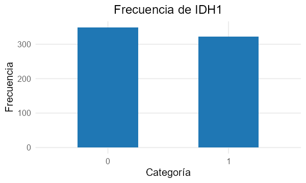

#### TP53

| Categoría | Frecuencia | Porcentaje |
| --- | --- | --- |
| 0 | 401 | 59.76 |
| 1 | 270 | 40.24 |

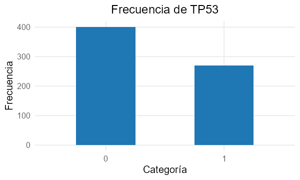

#### ATRX

| Categoría | Frecuencia | Porcentaje |
| --- | --- | --- |
| 0 | 499 | 74.37 |
| 1 | 172 | 25.63 |

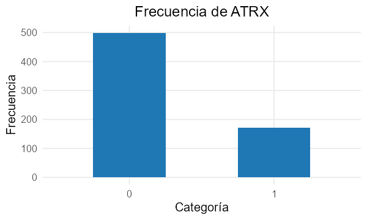

#### PTEN

| Categoría | Frecuencia | Porcentaje |
| --- | --- | --- |
| 0 | 558 | 83.16 |
| 1 | 113 | 16.84 |

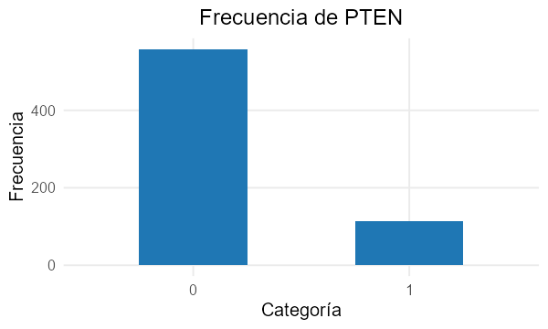

#### EGFR

| Categoría | Frecuencia | Porcentaje |
| --- | --- | --- |
| 0 | 593 | 88.38 |
| 1 | 78 | 11.62 |

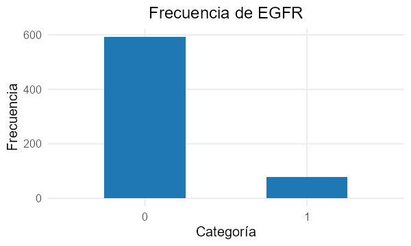

#### CIC

| Categoría | Frecuencia | Porcentaje |
| --- | --- | --- |
| 0 | 579 | 86.29 |
| 1 | 92 | 13.71 |

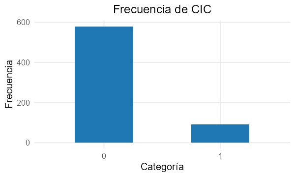

#### MUC16

| Categoría | Frecuencia | Porcentaje |
| --- | --- | --- |
| 0 | 597 | 88.97 |
| 1 | 74 | 11.03 |

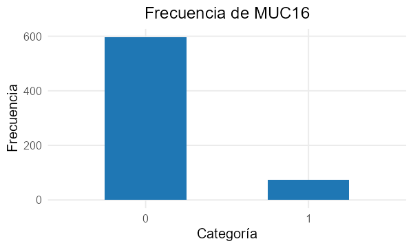

#### PIK3CA

| Categoría | Frecuencia | Porcentaje |
| --- | --- | --- |
| 0 | 614 | 91.51 |
| 1 | 57 | 8.49 |

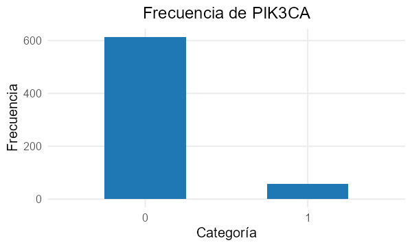

#### NF1

| Categoría | Frecuencia | Porcentaje |
| --- | --- | --- |
| 0 | 615 | 91.65 |
| 1 | 56 | 8.35 |

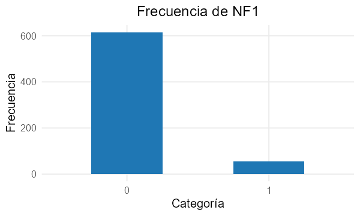

#### PIK3R1

| Categoría | Frecuencia | Porcentaje |
| --- | --- | --- |
| 0 | 632 | 94.19 |
| 1 | 39 | 5.81 |

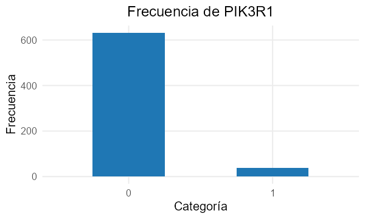

#### FUBP1

| Categoría | Frecuencia | Porcentaje |
| --- | --- | --- |
| 0 | 629 | 93.74 |
| 1 | 42 | 6.26 |

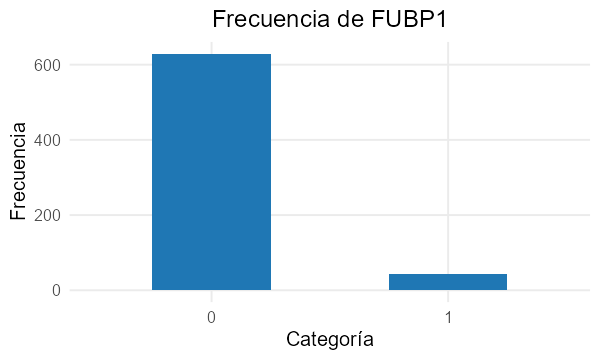

#### RB1

| Categoría | Frecuencia | Porcentaje |
| --- | --- | --- |
| 0 | 638 | 95.08 |
| 1 | 33 | 4.92 |

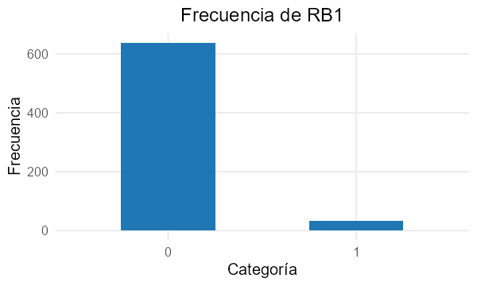

#### NOTCH1

| Categoría | Frecuencia | Porcentaje |
| --- | --- | --- |
| 0 | 638 | 95.08 |
| 1 | 33 | 4.92 |

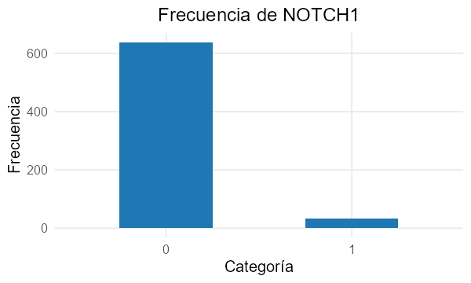

#### BCOR

| Categoría | Frecuencia | Porcentaje |
| --- | --- | --- |
| 0 | 649 | 96.72 |
| 1 | 22 | 3.28 |

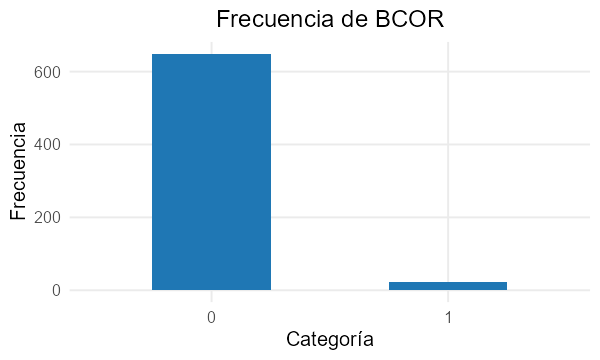

#### CSMD3

| Categoría | Frecuencia | Porcentaje |
| --- | --- | --- |
| 0 | 648 | 96.57 |
| 1 | 23 | 3.43 |

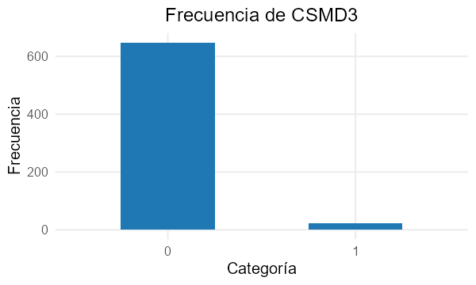

#### SMARCA4

| Categoría | Frecuencia | Porcentaje |
| --- | --- | --- |
| 0 | 648 | 96.57 |
| 1 | 23 | 3.43 |

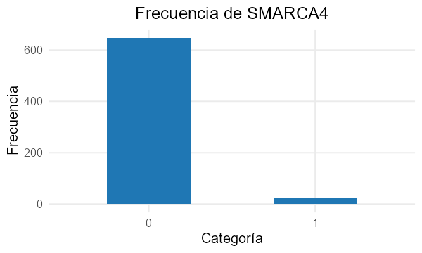

#### GRIN2A

| Categoría | Frecuencia | Porcentaje |
| --- | --- | --- |
| 0 | 652 | 97.17 |
| 1 | 19 | 2.83 |

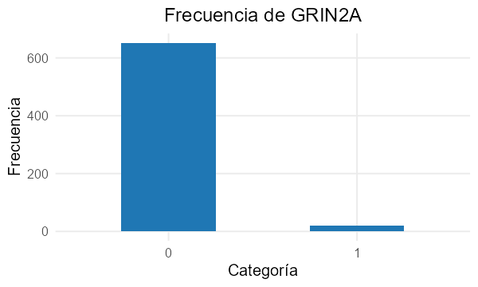

#### IDH2

| Categoría | Frecuencia | Porcentaje |
| --- | --- | --- |
| 0 | 650 | 96.87 |
| 1 | 21 | 3.13 |

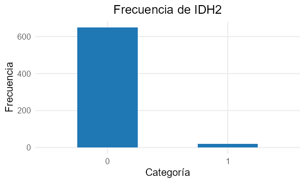

#### FAT4

| Categoría | Frecuencia | Porcentaje |
| --- | --- | --- |
| 0 | 653 | 97.32 |
| 1 | 18 | 2.68 |

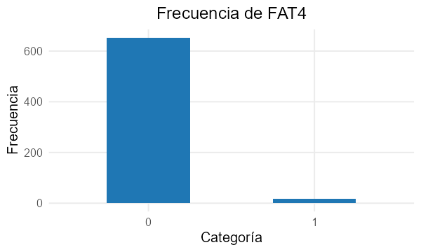

#### PDGFRA

| Categoría | Frecuencia | Porcentaje |
| --- | --- | --- |
| 0 | 653 | 97.32 |
| 1 | 18 | 2.68 |

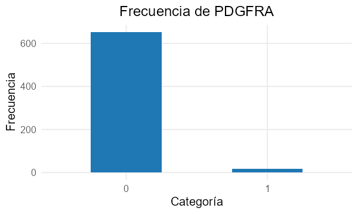

Las variables genéticas presentan una distribución predominantemente concentrada en la categoría `0`, correspondiente a la ausencia de mutación, mientras que la categoría `1` representa su presencia.

Entre los genes analizados, IDH1 presenta la mayor proporción de casos con mutación, con 322 registros (47,99 %), seguido de TP53, con 270 registros (40,24 %). A continuación se encuentran ATRX con 25,63 %, PTEN con 16,84 %, CIC con 13,71 %, EGFR con 11,62 % y MUC16 con 11,03 %. En un nivel intermedio se encuentran PIK3CA (8,49 %), NF1 (8,35 %) y FUBP1 (6,26 %), mientras que PIK3R1 (5,81 %), RB1 (4,92 %) y NOTCH1 (4,92 %) presentan proporciones inferiores al 6 %. Finalmente, genes como CSMD3 (3,43 %), SMARCA4 (3,43 %), IDH2 (3,13 %), BCOR (3,28 %), GRIN2A (2,83 %), FAT4 (2,68 %) y PDGFRA (2,68 %) muestran una presencia de mutaciones relativamente baja en el conjunto analizado.

En términos generales, se observa una alta variabilidad en la frecuencia de las mutaciones entre los genes, con una mayor concentración en IDH1 y TP53 y una presencia considerablemente menor en los genes restantes. Esto evidencia que las alteraciones genéticas no se distribuyen de manera uniforme en la muestra y que algunos genes presentan una representación mutacional mucho mayor que otros.

## 1.5 Análisis Bivariado

En esta sección se analiza la relación entre las variables independientes y la variable objetivo `Grade`, considerando tanto variables categóricas como numéricas. Para las variables categóricas se examinan las frecuencias absolutas y relativas de sus categorías según cada nivel de `Grade`, complementando las comparaciones mediante gráficos de barras agrupadas. Para la variable numérica `Age_at_diagnosis`, se analiza y compara su distribución entre los grupos de `Grade` mediante estadísticos descriptivos y gráficos de caja. Finalmente, se realiza un análisis de correlación entre las variables numéricas para evaluar la intensidad y dirección de las relaciones entre ellas.

### 1.5.1 `Grade` - `Age_at_diagnosis`

```r
medias <- train_data |>
  group_by(Grade) |>
  summarise(media = mean(Age_at_diagnosis))

ggplot(train_data, aes(x = Grade, y = Age_at_diagnosis)) +
  geom_boxplot(fill = "#1E90FF", alpha = 0.6, color = "black") +
  geom_point(data = medias, aes(x = Grade, y = media), color = "red", size = 3) +
  labs(title = "Distribución de la edad según el grado del tumor",
       x = "Grado del tumor (Grade)", y = "Edad al diagnóstico")
```

[figure not shown]

```r
age_grade <- train_data |>
  group_by(Grade) |>
  summarise(
    n       = n(),
    media   = mean(Age_at_diagnosis),
    ds      = sd(Age_at_diagnosis),
    mediana = median(Age_at_diagnosis),
    minimo  = min(Age_at_diagnosis),
    maximo  = max(Age_at_diagnosis),
    Q1      = quantile(Age_at_diagnosis, 0.25),
    Q3      = quantile(Age_at_diagnosis, 0.75),
    IQR     = Q3 - Q1
  ) |>
  mutate(variable = "Age_at_diagnosis", niveles = as.character(Grade)) |>
  select(variable, niveles, Grade, n, media, ds, mediana, minimo, maximo, Q1, Q3, IQR)

kable(age_grade, digits = 6) |>
  kable_styling(bootstrap_options = c("striped", "condensed"), full_width = TRUE) |>
  scroll_box(width = "100%")
```

| variable | niveles | Grade | n | media | ds | mediana | minimo | maximo | Q1 | Q3 | IQR |
| --- | --- | --- | --- | --- | --- | --- | --- | --- | --- | --- | --- |
| Age_at_diagnosis | 0 | 0 | 389 | 44.10434 | 13.20099 | 41.89 | 14.42 | 87.00 | 33.9100 | 54.27 | 20.3600 |
| Age_at_diagnosis | 1 | 1 | 282 | 60.74876 | 13.45075 | 61.49 | 21.73 | 89.29 | 52.7525 | 69.88 | 17.1275 |

El análisis bivariado de la edad al diagnóstico (`Age_at_diagnosis`) según el grado del tumor (`Grade`) muestra una clara separación clínico-demográfica entre los Gliomas de Bajo Grado (LGG / Grado 0) y el Glioblastoma Multiforme (GBM / Grado 1).

**Distribución Estadística**

- *Glioma de Bajo Grado (LGG / Grado 0):* En la muestra de 389 pacientes, la edad promedio al diagnóstico es de 44,10 ± 13,20 años y la mediana alcanza los 41,89 años. El 50% central de los pacientes se concentra entre los 33,91 ($Q_1$) y 54,27 años ($Q_3$), registrando un rango intercuartílico (IQR) de 20,36 años.
- *Glioblastoma Multiforme (GBM / Grado 1):* En el grupo de 282 pacientes, la media asciende a 60,75 ± 13,45 años, con una mediana de 61,49 años. Su intervalo intercuartílico se ubica entre los 52,75 ($Q_1$) y 69,88 años ($Q_3$), representando un IQR de 17,13 años.

**Separación de Poblaciones y Análisis de Outliers**

Existe una baja superposición en el núcleo de ambas distribuciones. El 75% de los pacientes diagnosticados con LGG tiene 54,27 años o menos, mientras que el 75% de los casos de GBM presenta una edad de diagnóstico igual o superior a 52,75 años. Esto evidencia una diferencia importante en la edad de diagnóstico entre ambos niveles de `Grade`, con una mayor concentración de edades en los pacientes con GBM.

En el análisis univariado de `Age_at_diagnosis`, considerando la distribución global de todos los pacientes, no se identificaron valores atípicos mediante el criterio del rango intercuartílico (IQR). Sin embargo, al analizar la edad de manera bivariada según `Grade`, sí aparecen observaciones que pueden clasificarse como outliers dentro de los grupos individuales. Esto ocurre porque cada nivel de `Grade` presenta su propia distribución, con diferentes valores de $Q_1$, $Q_3$ e IQR; por lo tanto, una edad que se encuentra dentro del rango esperado de la población total puede resultar extrema cuando se compara únicamente con la distribución de su grupo.

- *Valores Atípicos en Grado 0:* Se identifica un valor atípico superior de 87 años, que resulta inusual dentro de la distribución de edades de los pacientes con LGG.
- *Valores Atípicos en Grado 1:* El grupo GBM presenta valores atípicos inferiores entre 21,73 y 25,20 años, correspondientes a edades considerablemente menores que las habituales dentro de este grupo y que representan casos poco frecuentes de glioblastoma en adultos jóvenes.

#### 1.5.1.1 Prueba U de Mann–Whitney

Para evaluar si existen diferencias estadísticamente significativas en la edad al diagnóstico entre los grupos de `Grade`, se utiliza la prueba U de Mann–Whitney, debido a que la variable `Age_at_diagnosis` no presenta una distribución normal según la prueba de Shapiro-Wilk.

- **Hipótesis nula ($H_0$):** no existen diferencias estadísticamente significativas en la distribución de `Age_at_diagnosis` entre los grupos `Grade = 0` y `Grade = 1`.
- **Hipótesis alternativa ($H_1$):** existen diferencias estadísticamente significativas en la distribución de `Age_at_diagnosis` entre los grupos `Grade = 0` y `Grade = 1`.

Se utiliza un nivel de significancia de $\alpha = 0,05$.

```r
grupo_0 <- train_data |> filter(Grade == 0) |> pull(Age_at_diagnosis)
grupo_1 <- train_data |> filter(Grade == 1) |> pull(Age_at_diagnosis)

# wilcox.test reporta como estadístico W el U de Mann-Whitney del primer grupo
mw_test <- wilcox.test(grupo_0, grupo_1, alternative = "two.sided", exact = FALSE)

cat(sprintf("Estadístico U: %.4f\n", mw_test$statistic))
```

```
## Estadístico U: 21042.5000
```

```r
cat(sprintf("p-value: %.4f\n", mw_test$p.value))
```

```
## p-value: 0.0000
```

El resultado obtenido fue un estadístico U de 21042,5 y un p-value < 0,0001, por lo que, considerando un nivel de significancia de $\alpha = 0,05$, se rechaza la hipótesis nula. Esto indica que existe una diferencia estadísticamente significativa en la distribución de la variable entre los grupos LGG y GBM. Por lo tanto, los resultados sugieren que esta variable presenta un comportamiento diferente según el grado del glioma, aunque la prueba por sí sola no permite establecer una relación causal.

```r
analisis_bivariado <- function(df, target, variable, etiquetas = NULL,
                               titulo = NULL, xlabel = NULL) {

  df_plot <- df |>
    count(.data[[target]], .data[[variable]], name = "n", .drop = FALSE) |>
    group_by(.data[[target]]) |>
    mutate(porcentaje = round(n / sum(n) * 100, 1)) |>
    ungroup() |>
    rename(categoria = all_of(variable))

  df_plot$categoria <- as.character(df_plot$categoria)

  if (!is.null(etiquetas)) {
    df_plot$categoria <- dplyr::recode(df_plot$categoria, !!!etiquetas)
  }

  df_plot <- df_plot |>
    mutate(grupo = factor(sprintf("%s %s", target, .data[[target]]))) |>
    select(all_of(target), grupo, categoria, n, porcentaje)

  if (is.null(titulo)) titulo <- sprintf("Distribución de %s según %s", variable, target)
  if (is.null(xlabel)) xlabel <- variable

  fig <- ggplot(df_plot, aes(x = factor(categoria, levels = sort(unique(categoria))),
                             y = n, fill = grupo)) +
    geom_col(position = position_dodge(width = 0.8), width = 0.8) +
    geom_text(aes(label = sprintf("%d (%.1f%%)", n, porcentaje)),
              position = position_dodge(width = 0.8), vjust = -0.4, size = 3) +
    scale_fill_manual(values = c("#1f77b4", "#ff7f0e"), name = target) +
    scale_y_continuous(expand = expansion(mult = c(0, 0.12))) +
    labs(title = titulo, x = xlabel, y = "Cantidad de pacientes") +
    theme(legend.position = "right")

  list(tabla = df_plot, grafico = fig)
}
```

### 1.5.2 `Grade` - `Gender`

```r
tabla_gender_bivariada <- analisis_bivariado(
  train_data,
  target    = "Grade",
  variable  = "Gender",
  etiquetas = c("0" = "Hombre", "1" = "Mujer"),
  titulo    = "Distribución del género según Grade",
  xlabel    = "Género"
)
tabla_gender_bivariada$grafico
```

[figure not shown]

La distribución del género presenta diferencias entre los dos niveles de Grade. En Grade 0, se registran 220 hombres (56,6%) y 169 mujeres (43,4%), mientras que en Grade 1 se observan 178 hombres (63,1%) y 104 mujeres (36,9%). En ambos niveles predomina el género masculino; sin embargo, esta predominancia es mayor en Grade 1, donde los hombres representan el 63,1% frente al 56,6% en Grade 0. Por otro lado, la proporción de mujeres disminuye de 43,4% en Grade 0 a 36,9% en Grade 1. En términos descriptivos, estos resultados sugieren una mayor representación masculina en Grade 1, aunque las diferencias observadas no permiten establecer por sí solas una asociación estadísticamente significativa entre el género y Grade.

#### 1.5.2.1 Prueba de independencia: $\chi^2$

En este caso, se analiza la relación entre `Gender` y `Grade` mediante una prueba de independencia de Chi-cuadrado ($\chi^2$).

Se utiliza un nivel de significancia de $\alpha = 0,05$:

- **Hipótesis nula ($H_0$):** `Gender` y `Grade` son independientes; no existe una asociación estadísticamente significativa entre ambas variables.
- **Hipótesis alternativa ($H_1$):** `Gender` y `Grade` no son independientes; existe una asociación estadísticamente significativa entre ambas variables.

```r
tabla_gender_grade <- table(train_data$Gender, train_data$Grade)

chi2_gender <- chisq.test(tabla_gender_grade)

cat(sprintf("\nEstadístico χ²: %.4f\n", chi2_gender$statistic))
```

```
##
## Estadístico χ²: 2.6543
```

```r
cat(sprintf("p-value: %.4f\n", chi2_gender$p.value))
```

```
## p-value: 0.1033
```

```r
cat(sprintf("Grados de libertad: %d\n", chi2_gender$parameter))
```

```
## Grados de libertad: 1
```

Con un nivel de significancia de $\alpha = 0,05$, el estadístico de Chi-cuadrado obtenido fue $\chi^2(1) = 2,6543$, con un p-value de $0,1033$. Debido a que $p = 0,1033 > 0,05$, no se rechaza la hipótesis nula ($H_0$). Por lo tanto, no se encuentra evidencia estadísticamente significativa de una asociación entre Gender y Grade en el conjunto de datos analizado; es decir, los resultados son compatibles con la independencia entre ambas variables.

### 1.5.3 `Grade` - `Race`

```r
tabla_race_bivariada <- analisis_bivariado(
  train_data,
  target    = "Grade",
  variable  = "Race",
  etiquetas = c("0" = "White", "1" = "Black or African American",
                "2" = "Asian", "3" = "American Indian"),
  titulo    = "Distribución del grupo racial según Grade",
  xlabel    = "Grupo racial"
)
tabla_race_bivariada$grafico + scale_x_discrete(labels = label_wrap(14))
```

[figure not shown]

La distribución por grupo racial muestra un predominio marcado de la población blanca en ambos niveles de Grade. En Grade 0, el grupo White concentra 365 pacientes (93,8%), mientras que en Grade 1 representa 246 pacientes (87,2%). El grupo Black or African American constituye el segundo grupo con mayor representación, con 16 pacientes (4,1%) en Grade 0 y 30 pacientes (10,6%) en Grade 1. Por su parte, la población asiática presenta una participación reducida, con 7 casos (1,8%) en Grade 0 y 6 casos (2,1%) en Grade 1, mientras que American Indian or Alaska Native presenta una ocurrencia prácticamente nula, con 1 caso (0,3%) en Grade 0 y ningún caso en Grade 1.

En términos comparativos, se observa que la proporción del grupo White disminuye en Grade 1, pasando de 93,8% a 87,2%, mientras que el grupo Black or African American aumenta de 4,1% a 10,6%.

Además, si bien existen diferencias en la distribución de los grupos raciales entre los niveles de Grade, estos resultados deben analizarse con precaución, ya que la muestra está fuertemente concentrada en el grupo White y algunas de las demás categorías presentan muy pocas observaciones.

#### 1.5.3.1 Prueba de independencia: $\chi^2$

Para realizar la prueba de independencia entre `Grade` y `Race`, se decidió reagrupar las categorías de la variable racial debido a las bajas frecuencias observadas en algunos grupos. En particular, las categorías Asian y American Indian or Alaska Native presentan un número reducido de observaciones, lo que puede generar frecuencias esperadas demasiado bajas y afectar la validez de la prueba estadística.

Por esta razón, se mantuvo la categoría White, que representa la mayoría de los registros, y se agruparon Black or African American, Asian y American Indian or Alaska Native en una nueva categoría denominada Other racial groups.

De esta manera, la variable `Race` queda conformada por dos categorías: White y Other racial groups, permitiendo realizar la prueba de independencia con una distribución de frecuencias más adecuada.

```r
race_agrupada <- dplyr::recode(
  as.character(train_data$Race),
  "0" = "White",
  "1" = "Other racial groups",
  "2" = "Other racial groups",
  "3" = "Other racial groups"
)

tabla_race <- table(Grade = train_data$Grade, Race = race_agrupada)

kable(as.data.frame.matrix(tabla_race)) |>
  kable_styling(bootstrap_options = c("striped", "condensed"), full_width = FALSE)
```

|  | Other racial groups | White |
| --- | --- | --- |
| 0 | 24 | 365 |
| 1 | 36 | 246 |

```r
chi2_race <- chisq.test(tabla_race)

cat(sprintf("Chi-cuadrado: %.4f\n", chi2_race$statistic))
```

```
## Chi-cuadrado: 7.9450
```

```r
cat(sprintf("Grados de libertad: %d\n", chi2_race$parameter))
```

```
## Grados de libertad: 1
```

```r
cat(sprintf("Valor p: %.4f\n", chi2_race$p.value))
```

```
## Valor p: 0.0048
```

Dado que el valor p = 0,0048 es menor que el nivel de significancia de 0.05, se rechaza la hipótesis nula de independencia. Por lo tanto, existe evidencia estadísticamente significativa de una asociación entre `Grade` y `Race` en el conjunto de datos.

Esto indica que la distribución de los pacientes entre LGG (Grade 0) y GBM (Grade 1) presenta diferencias según el grupo racial considerado. Sin embargo, este resultado debe interpretarse con cautela, ya que la variable `Race` fue previamente agrupada en White y Other racial groups debido a las bajas frecuencias de algunas categorías originales.

Es importante señalar que la prueba de independencia permite identificar una asociación estadística, pero no implica que el grupo racial sea la causa de las diferencias observadas en el grado tumoral.

### 1.5.4 `Grade` - `variables genéticas`

Se analiza la distribución de las variables genéticas según los niveles de Grade, diferenciando entre pacientes con glioma de bajo grado (LGG, Grade 0) y glioblastoma (GBM, Grade 1). Esta comparación permite identificar diferencias descriptivas en la presencia o ausencia de mutaciones entre ambos grupos.

```r
prueba_independencia <- function(df, target, variable, alpha = 0.05) {

  tabla <- table(df[[variable]], df[[target]])

  # chi2 con y sin corrección de Yates
  chi2_c <- suppressWarnings(chisq.test(tabla, correct = TRUE))
  chi2_s <- suppressWarnings(chisq.test(tabla, correct = FALSE))
  esperadas <- chi2_c$expected

  supuesto_valido <- all(esperadas >= 5)
  usar_fisher <- all(dim(tabla) == c(2, 2)) && !supuesto_valido

  if (usar_fisher) {
    p_valor    <- fisher.test(tabla)$p.value
    test_usado <- "Fisher exacto"
  } else {
    p_valor    <- chi2_c$p.value
    test_usado <- "Chi-cuadrado"
  }

  list(
    variable        = variable,
    test            = test_usado,
    chi2            = unname(chi2_s$statistic),
    chi2_yates      = unname(chi2_c$statistic),
    dof             = unname(chi2_c$parameter),
    p_value         = p_valor,
    expected_min    = min(esperadas),
    supuesto_valido = supuesto_valido,
    significativo   = p_valor < alpha
  )
}
```

```r
crear_menu_gen <- function(df, target, variable, interpretacion,
                           etiquetas = NULL, width = 7, height = 4) {

  res <- analisis_bivariado(
    df        = df,
    target    = target,
    variable  = variable,
    etiquetas = etiquetas
  )

  imagen_base64 <- ggplot_a_base64(res$grafico, width = width, height = height)

  resultado_test <- prueba_independencia(df, target, variable)

  color_resultado <- if (resultado_test$significativo) "#1a7f37" else "#6e7781"
  conclusion <- if (resultado_test$significativo) {
    "se rechaza H₀: existe asociación estadísticamente significativa"
  } else {
    "no se rechaza H₀: no hay evidencia de asociación significativa"
  }

  estadistico_str <- if (resultado_test$test == "Chi-cuadrado") {
    sprintf("χ²(%d) = %.4f", resultado_test$dof, resultado_test$chi2)
  } else {
    "Fisher exacto (frecuencia esperada < 5)"
  }

  html_test <- sprintf(
    '<div style="margin-top: 16px; padding: 10px 14px; border-left: 4px solid %s; background-color: rgba(110, 119, 129, 0.08); border-radius: 4px; font-size: 14px;"><b>Prueba de independencia (%s):</b> %s, p-value = %.4f → <span style="color:%s; font-weight:600;">%s</span> (α = 0.05)</div>',
    color_resultado, resultado_test$test, estadistico_str,
    resultado_test$p_value, color_resultado, conclusion
  )

  # El texto se muestra como un solo párrafo, igual que en el notebook
  texto <- str_squish(interpretacion)

  sprintf(
    '<details class="gen-details"><summary>%s</summary><div style="padding: 20px;"><p style="line-height: 1.7; text-align: justify; margin-top: 0;">%s</p>%s<div style="text-align: center; margin-top: 20px;"><img src="%s" style="max-width: 100%%; height: auto; border-radius: 4px;"></div></div></details>',
    variable, texto, html_test, imagen_base64
  )
}
```

```r
interpretaciones_genes <- list(

  IDH1 = "Al comparar la presencia de la mutación en IDH1 entre los dos niveles de Grade,
se observa una diferencia bastante marcada. En los LGG (Grade 0), 303 pacientes (77,9%)
presentan la mutación de IDH1, mientras que 86 pacientes (22,1%) no presentan la mutación.
En contraste, en los GBM (Grade 1), solamente 19 pacientes (6,7%) presentan la mutación,
mientras que 263 pacientes (93,3%) no la presentan.

Esto muestra un patrón muy marcado donde la mutación de IDH1 es mucho más frecuente en
los LGG que en los GBM. En los LGG, aproximadamente 8 de cada 10 pacientes presentan la
mutación, mientras que en los GBM ocurre en aproximadamente 7 de cada 100 pacientes.
Por el contrario, la ausencia de la mutación predomina ampliamente en los GBM.

Desde una perspectiva descriptiva, estos resultados sugieren que la presencia de la mutación
IDH1 está fuertemente asociada con los LGG en este conjunto de datos, mientras que su ausencia
caracteriza en mayor proporción a los GBM.",

  TP53 = "Al comparar la presencia de la mutación en TP53 entre los dos niveles de Grade, se observa una
diferencia en su distribución. En los LGG (Grade 0), 177 pacientes (45,5 %) presentan la mutación
de TP53, mientras que 212 pacientes (54,5 %) no la presentan. En contraste, en los GBM (Grade 1),
93 pacientes (33,0 %) presentan la mutación, mientras que 189 pacientes (67,0 %) no presentan la mutación.

Estos resultados muestran que la ausencia de la mutación TP53 predomina en ambos grupos, aunque es más
frecuente en los GBM. En los LGG, aproximadamente 5 de cada 10 pacientes presentan la mutación,
mientras que en los GBM la presentan aproximadamente 3 de cada 10 pacientes. Por otro lado, la presencia
de TP53 es relativamente mayor en los LGG que en los GBM.",

  ATRX = "La gráfica muestra una diferencia clara en la distribución de la mutación de ATRX entre los dos grados
de glioma. En el Grado 0, la ausencia de mutación de ATRX es mayoritaria ya que se observa en 242 pacientes
(62,2%), mientras que la presencia de la mutación aparece en 147 pacientes (37,8%).

En contraste, en el Grado 1, la ausencia de mutación de ATRX es todavía más predominante, con 257 pacientes (91,1%),
mientras que únicamente 25 pacientes (8,9%) presentan la mutación.

Esto indica que la presencia de una mutación en ATRX está considerablemente más representada en el Grado 0 que
en el Grado 1. En términos relativos, la mutación aparece en el 37,8% de los pacientes de Grado 0 frente al 8,9%
de los pacientes de Grado 1. Por tanto, existe una diferencia importante en la distribución de ATRX entre ambas clases.",

  PTEN = "En la gráfica, para el Grado 0, la ausencia de mutación en PTEN es predominante, con 369 pacientes (94,9%), mientras que
únicamente 20 pacientes (5,1%) presentan la mutación. En cambio, en el Grado 1, aunque la ausencia continúa siendo
mayoritaria, su proporción disminuye considerablemente hasta 189 pacientes (67,0%), mientras que la presencia de la
mutación aumenta hasta 93 pacientes (33,0%).

Por lo tanto, se observa que la mutación de PTEN está considerablemente más representada en el Grado 1. Comparando las
proporciones, la presencia de PTEN pasa de 5,1% en Grado 0 a 33,0% en Grado 1, lo que representa una diferencia de 27,9
puntos porcentuales.",

  EGFR = "En el Grado 0, la ausencia de mutación de EGFR es predominante, con 366 pacientes (94,1%), mientras que solo
23 pacientes (5,9%) presentan la mutación. Para el Grado 1, la ausencia también es mayoritaria, pero disminuye
a 227 pacientes (80,5%), mientras que la presencia de la mutación aumenta a 55 pacientes (19,5%).

Por lo tanto, se observa que la presencia de la mutación en EGFR es más frecuente en el Grado 1. La proporción
de pacientes con EGFR mutado pasa de 5,9% en el Grado 0 a 19,5% en el Grado 1, lo que representa un incremento de
13,6 puntos porcentuales.",

  CIC = "Para el caso del gen CIC, en el Grado 0, la ausencia de mutación es mayoritaria, con 300 pacientes (77,1%), mientras que 89 pacientes (22,9%)
presentan la mutación. En el Grado 1, la ausencia de mutación aumenta considerablemente hasta 279 pacientes (98,9%),
mientras que solamente 3 pacientes (1,1%) presentan una mutación en CIC.

Por tanto, la presencia de la mutación en CIC es mucho más frecuente en el Grado 0. La proporción disminuye de 22,9%
en el Grado 0 a apenas 1,1% en el Grado 1, lo que representa una diferencia de 21,8 puntos porcentuales.

Este comportamiento resulta especialmente interesante para el análisis de clasificación, ya que la distribución de
CIC cambia considerablemente entre las dos clases. En particular, la presencia de mutación en CIC parece estar asociada con el
Grado 0, mientras que su ausencia está presente en prácticamente todos los pacientes de Grado 1. Esto sugiere que CIC
podría ser una variable con un alto poder discriminativo para diferenciar ambas categorías.",

  MUC16 = "La gráfica muestra la distribución de la mutación de MUC16 en los pacientes de Grado 0 y Grado 1. En ambos grupos
predomina la ausencia de la mutación, aunque se observa una diferencia en la proporción de pacientes
que presentan la alteración.

En el Grado 0, la ausencia corresponde a 358 pacientes (92,0%), mientras que 31 pacientes (8,0%) presentan
la mutación. En el Grado 1, la ausencia se presenta en 239 pacientes (84,8%), mientras que 43 pacientes (15,2%)
presentan la mutación.

Por tanto, la presencia de la mutación de MUC16 es más frecuente en el Grado 1. La proporción aumenta de 8,0% en el
Grado 0 a 15,2% en el Grado 1, lo que representa una diferencia de 7,2 puntos porcentuales.

A diferencia de variables como PTEN o CIC, la diferencia entre ambos grados en MUC16 es más moderada. Esto sugiere
que MUC16 podría aportar cierta información para diferenciar las clases, pero su capacidad discriminativa individual
parece menor a partir de esta distribución.",

  PIK3CA = "La distribución de PIK3CA es bastante similar entre los dos grupos de Grade. La ausencia de la alteración es
predominante tanto en Grade 0 (92,3 %) como en Grade 1 (90,4 %), mientras que su presencia representa únicamente
el 7,7 % y 9,6 %, respectivamente. Aunque se observa una proporción ligeramente mayor de presencia de mutación de PIK3CA en
Grade 1, la diferencia es pequeña (1,9 puntos porcentuales). Por lo tanto, a partir de esta comparación descriptiva,
PIK3CA no presenta una diferencia marcada entre ambos grados.",
```

```r
  NF1 = "La distribución de mutación de NF1 presenta una ligera diferencia entre los grupos de Grade. La presencia de mutación de NF1 es mayor en
Grade 1 (10,6 %) que en Grade 0 (6,7 %), mientras que la ausencia es predominante en ambos grupos. Esta diferencia
de 3,9 puntos porcentuales sugiere una posible mayor frecuencia de alteraciones en NF1 en los pacientes de Grade 1.
Sin embargo, debido a que la diferencia entre ambos grupos es relativamente pequeña y la ausencia de mutación de NF1 predomina
ampliamente, no se observa una separación marcada entre los grados a partir de esta variable.",

  PIK3R1 = "La distribución de PIK3R1 muestra una diferencia entre los grupos de Grade. La presencia de esta alteración es mayor
en Grade 1 (8,5 %) que en Grade 0 (3,9 %), con una diferencia de 4,6 puntos porcentuales. Sin embargo, la ausencia de  alteración del gen
PIK3R1 predomina claramente en ambos grupos, representando el 96,1 % de los casos en Grade 0 y el 91,5 % en Grade 1.

Por lo tanto, aunque se observa una mayor frecuencia de presencia de PIK3R1 en Grade 1, la diferencia no es lo
suficientemente marcada como para observar una separación clara entre los dos grupos únicamente mediante este análisis
descriptivo.",

  FUBP1 = "En términos descriptivos, FUBP1 presenta una distribución claramente diferente según el Grade. En Grade 0, la presencia de mutación
de FUBP1 alcanza el 10,3 % de los pacientes, mientras que en Grade 1 esta proporción disminuye considerablemente hasta
el 0,7 %. De manera consecuente, la ausencia de la variable es predominante en ambos grupos, aunque es especialmente alta
en Grade 1, donde alcanza el 99,3 %. Esta diferencia de 9,6 puntos porcentuales en la presencia de FUBP1 sugiere que esta
variable podría estar relacionada con la clasificación del grado tumoral y podría aportar información para diferenciar
entre ambos grupos.",

  RB1 = "La gráfica muestra la distribución  de RB1 entre los dos grupos de Grade y permite observar una diferencia apreciable
en la frecuencia de esta variable. En Grade 0, la ausencia de mutación de RB1 representa el 98,5 % de los pacientes (383 casos),
mientras que únicamente el 1,5 % presenta mutación de RB1 (6 casos). Por otro lado, en Grade 1, la ausencia corresponde al 90,4 %
(255 casos), mientras que la presencia aumenta hasta el 9,6 % (27 casos).

Por lo tanto, la presencia de mutación de RB1 es considerablemente más frecuente en Grade 1, donde alcanza el 9,6 %, frente al 1,5 %
observado en Grade 0. Esto supone una diferencia de aproximadamente 8,1 puntos porcentuales. Aunque la ausencia continúa
siendo la categoría predominante en ambos grupos, el aumento de la presencia de alteración del gen RB1 en Grade 1 genera una separación
bastante visible entre las distribuciones.",

  NOTCH1 = "En términos descriptivos, NOTCH1 presenta una distribución claramente diferenciada según el Grade. En Grade 0,
el 8,5 % de los pacientes presenta mutación de NOTCH1, mientras que en Grade 1 no se observa ningún caso con presencia de
esta variable. Por otro lado, la ausencia de alteración de NOTCH1 es predominante en ambos grupos, aunque alcanza el 100 %
en Grade 1. Esta diferencia sugiere que la presencia de mutación de NOTCH1 podría estar relacionada con la clasificación del
grado tumoral y podría ser una característica útil para distinguir entre ambos grupos.",

  BCOR = "La gráfica muestra la distribución de BCOR según el Grade y, a diferencia de algunas de las variables anteriores,
presenta un comportamiento muy similar entre ambos grupos. En Grade 0, el 96,7 % de los pacientes presenta ausencia
de mutación de BCOR (376 casos), mientras que el 3,3 % presenta su presencia (13 casos). En Grade 1, la ausencia corresponde al
96,8 % (273 casos) y la presencia al 3,2 % (9 casos).

Las proporciones son prácticamente iguales entre los dos grados. La presencia de alteración del gen BCOR solo difiere en 0,1 puntos
porcentuales, siendo ligeramente mayor en Grade 0 (3,3 %) que en Grade 1 (3,2 %). De manera similar, la ausencia
presenta una diferencia mínima de 0,1 puntos porcentuales. Esto indica que no existe una separación visual relevante
entre los grupos respecto a esta variable.",

  CSMD3 = "En términos descriptivos, CSMD3 presenta una distribución bastante similar entre los dos niveles de Grade. La presencia
de esta variable es ligeramente mayor en Grade 1 (4,3 %) que en Grade 0 (2,8 %), mientras que la ausencia se mantiene
como la categoría predominante, con 95,7 % y 97,2 %, respectivamente. Aunque este comportamiento muestra una pequeña
diferencia entre los grupos, la magnitud de la variación es reducida, por lo que no se aprecia una separación marcada
entre Grade 0 y Grade 1 a partir de CSMD3.",

  SMARCA4 = "La distribución de SMARCA4 muestra algunas diferencias entre los dos grupos de Grade. En Grade 0, la presencia de
mutación de SMARCA4 se encuentra en el 4,9 % de los pacientes, mientras que en Grade 1 solamente alcanza el 1,4 %. Esto significa
que la presencia de esta variable es aproximadamente 3,5 puntos porcentuales mayor en Grade 0. En ambos grupos,
sin embargo, predomina ampliamente la ausencia de mutación de SMARCA4, especialmente en Grade 1, donde representa el 98,6 % de
los casos. En consecuencia, aunque se observa una tendencia hacia una mayor presencia de mutación de SMARCA4 en Grade 0, la diferencia
entre los grupos es moderada y no permite considerar por sí sola a esta variable como un diferenciador fuerte del grado tumoral.",

  GRIN2A = "La distribución de GRIN2A muestra que la ausencia de mutación es predominante tanto en los pacientes de Grade 0 como en
los de Grade 1, con 98.7% y 95.0% de los casos, respectivamente. En contraste, la presencia de la mutación es poco
frecuente en ambos grupos, aunque presenta una mayor proporción en Grade 1 (5.0%) frente a Grade 0 (1.3%), lo que
representa una diferencia de 3.7 puntos porcentuales. Esta diferencia descriptiva indica una mayor frecuencia relativa
de mutaciones en GRIN2A entre los pacientes de Grade 1; sin embargo, debido a la baja cantidad de casos con presencia
de la mutación, no es suficiente para establecer por sí sola una asociación con el grado tumoral.",
```

```r
  IDH2 = "La distribución de IDH2 muestra una diferencia bastante marcada entre los dos grupos de Grade. En Grade 0, la presencia
de mutación de IDH2 corresponde al 4,9 % de los pacientes (19 casos), mientras que en Grade 1 solamente se presenta en el 0,7 %
(2 casos). Por el contrario, la ausencia de esta variable es muy elevada en ambos grupos, aunque es ligeramente mayor
en Grade 1, donde alcanza el 99,3 %, frente al 95,1 % observado en Grade 0.

La diferencia en la presencia de IDH2 es de 4,2 puntos porcentuales, lo que indica que esta característica aparece
con mayor frecuencia en Grade 0. Además, la distribución resulta especialmente interesante porque en Grade 1
prácticamente todos los pacientes presentan ausencia de alteración en el gen IDH2.",

  FAT4 = "En este caso, FAT4 presenta un comportamiento muy similar en los dos niveles de Grade. La presencia de esta variable
representa el 2,3 % de los casos en Grade 0 y aumenta ligeramente hasta el 3,2 % en Grade 1, mientras que la ausencia
se mantiene por encima del 96 % en ambos grupos. La diferencia de solo 0,9 puntos porcentuales indica que no existe
una separación clara entre los grados a partir de esta variable. Por lo tanto, FAT4 parece presentar una capacidad
discriminativa reducida por sí sola en este análisis bivariado.",

  PDGFRA = "La distribución de PDGFRA presenta una diferencia apreciable entre los dos grupos de Grade. En Grade 0, la presencia de mutación
de PDGFRA corresponde al 1,5 % de los pacientes (6 casos), mientras que en Grade 1 aumenta hasta el 4,3 % (12 casos).

Por otro lado, la ausencia de mutación de PDGFRA continúa siendo la categoría predominante en ambos grupos, con un 98,5 %
en Grade 0 y un 95,7 % en Grade 1. Esto representa una diferencia de 2,8 puntos porcentuales en la presencia de mutación de PDGFRA
entre ambos grados. Aunque la presencia de la variable sigue siendo poco frecuente, se observa una tendencia hacia una
mayor proporción en Grade 1. Por tanto, a diferencia de variables como FAT4, donde las proporciones eran prácticamente
iguales, PDGFRA muestra una separación algo más evidente entre los grupos."
)
```

```r
estilo_menus <- '<style>.gen-details { margin: 10px 0; border: 1px solid #d0d7de; border-radius: 8px; overflow: hidden; color: #1f2328; background-color: #ffffff; } .gen-details summary { padding: 14px 18px; cursor: pointer; font-size: 17px; font-weight: 500; background-color: #f6f8fa; } @media (prefers-color-scheme: dark) { .gen-details { color: #e6edf3; background-color: #0d1117; } .gen-details summary { background-color: #161b22; } }</style>'

html_genes <- map_chr(names(interpretaciones_genes), function(gen) {
  crear_menu_gen(
    train_data,
    target         = "Grade",
    variable       = gen,
    etiquetas      = c("0" = "Ausencia", "1" = "Presencia"),
    interpretacion = interpretaciones_genes[[gen]]
  )
})

cat(estilo_menus, "\n\n")
```

```r
cat(sprintf('<div style="margin-top: 20px;">%s</div>', paste(html_genes, collapse = "")), "\n")
```

**IDH1**

Al comparar la presencia de la mutación en IDH1 entre los dos niveles de Grade, se observa una diferencia bastante marcada. En los LGG (Grade 0), 303 pacientes (77,9%) presentan la mutación de IDH1, mientras que 86 pacientes (22,1%) no presentan la mutación. En contraste, en los GBM (Grade 1), solamente 19 pacientes (6,7%) presentan la mutación, mientras que 263 pacientes (93,3%) no la presentan. Esto muestra un patrón muy marcado donde la mutación de IDH1 es mucho más frecuente en los LGG que en los GBM. En los LGG, aproximadamente 8 de cada 10 pacientes presentan la mutación, mientras que en los GBM ocurre en aproximadamente 7 de cada 100 pacientes. Por el contrario, la ausencia de la mutación predomina ampliamente en los GBM. Desde una perspectiva descriptiva, estos resultados sugieren que la presencia de la mutación IDH1 está fuertemente asociada con los LGG en este conjunto de datos, mientras que su ausencia caracteriza en mayor proporción a los GBM.

**Prueba de independencia (Chi-cuadrado):** χ²(1) = 331.6225, p-value = 0.0000 → se rechaza H₀: existe asociación estadísticamente significativa (α = 0.05)

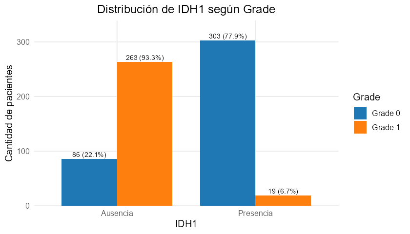

**TP53**

Al comparar la presencia de la mutación en TP53 entre los dos niveles de Grade, se observa una diferencia en su distribución. En los LGG (Grade 0), 177 pacientes (45,5 %) presentan la mutación de TP53, mientras que 212 pacientes (54,5 %) no la presentan. En contraste, en los GBM (Grade 1), 93 pacientes (33,0 %) presentan la mutación, mientras que 189 pacientes (67,0 %) no presentan la mutación. Estos resultados muestran que la ausencia de la mutación TP53 predomina en ambos grupos, aunque es más frecuente en los GBM. En los LGG, aproximadamente 5 de cada 10 pacientes presentan la mutación, mientras que en los GBM la presentan aproximadamente 3 de cada 10 pacientes. Por otro lado, la presencia de TP53 es relativamente mayor en los LGG que en los GBM.

**Prueba de independencia (Chi-cuadrado):** χ²(1) = 10.6610, p-value = 0.0014 → se rechaza H₀: existe asociación estadísticamente significativa (α = 0.05)

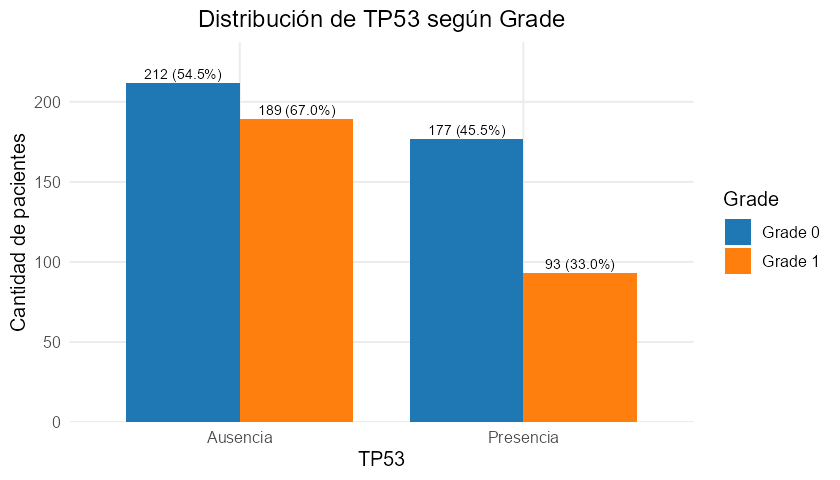

**ATRX**

La gráfica muestra una diferencia clara en la distribución de la mutación de ATRX entre los dos grados de glioma. En el Grado 0, la ausencia de mutación de ATRX es mayoritaria ya que se observa en 242 pacientes (62,2%), mientras que la presencia de la mutación aparece en 147 pacientes (37,8%). En contraste, en el Grado 1, la ausencia de mutación de ATRX es todavía más predominante, con 257 pacientes (91,1%), mientras que únicamente 25 pacientes (8,9%) presentan la mutación. Esto indica que la presencia de una mutación en ATRX está considerablemente más representada en el Grado 0 que en el Grado 1. En términos relativos, la mutación aparece en el 37,8% de los pacientes de Grado 0 frente al 8,9% de los pacientes de Grado 1. Por tanto, existe una diferencia importante en la distribución de ATRX entre ambas clases.

**Prueba de independencia (Chi-cuadrado):** χ²(1) = 71.7476, p-value = 0.0000 → se rechaza H₀: existe asociación estadísticamente significativa (α = 0.05)

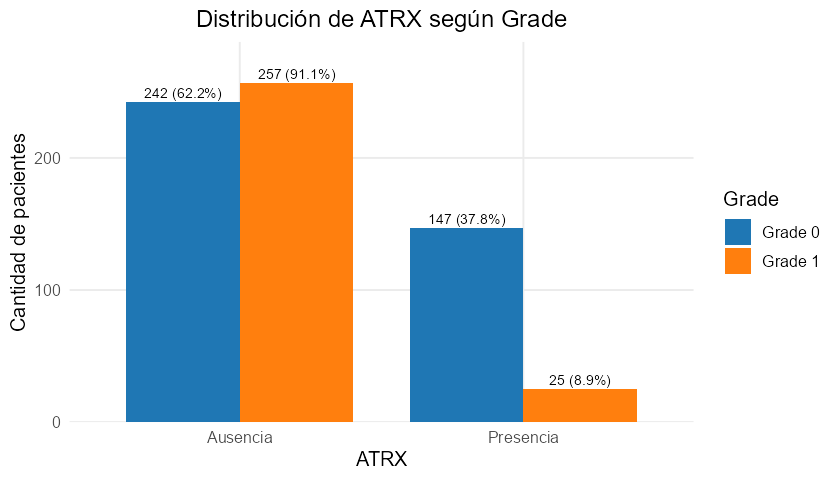

**PTEN**

En la gráfica, para el Grado 0, la ausencia de mutación en PTEN es predominante, con 369 pacientes (94,9%), mientras que únicamente 20 pacientes (5,1%) presentan la mutación. En cambio, en el Grado 1, aunque la ausencia continúa siendo mayoritaria, su proporción disminuye considerablemente hasta 189 pacientes (67,0%), mientras que la presencia de la mutación aumenta hasta 93 pacientes (33,0%). Por lo tanto, se observa que la mutación de PTEN está considerablemente más representada en el Grado 1. Comparando las proporciones, la presencia de PTEN pasa de 5,1% en Grado 0 a 33,0% en Grado 1, lo que representa una diferencia de 27,9 puntos porcentuales.

**Prueba de independencia (Chi-cuadrado):** χ²(1) = 90.4615, p-value = 0.0000 → se rechaza H₀: existe asociación estadísticamente significativa (α = 0.05)

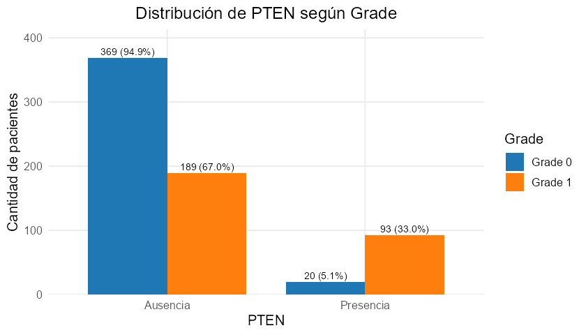

**EGFR**

En el Grado 0, la ausencia de mutación de EGFR es predominante, con 366 pacientes (94,1%), mientras que solo 23 pacientes (5,9%) presentan la mutación. Para el Grado 1, la ausencia también es mayoritaria, pero disminuye a 227 pacientes (80,5%), mientras que la presencia de la mutación aumenta a 55 pacientes (19,5%). Por lo tanto, se observa que la presencia de la mutación en EGFR es más frecuente en el Grado 1. La proporción de pacientes con EGFR mutado pasa de 5,9% en el Grado 0 a 19,5% en el Grado 1, lo que representa un incremento de 13,6 puntos porcentuales.

**Prueba de independencia (Chi-cuadrado):** χ²(1) = 29.3949, p-value = 0.0000 → se rechaza H₀: existe asociación estadísticamente significativa (α = 0.05)

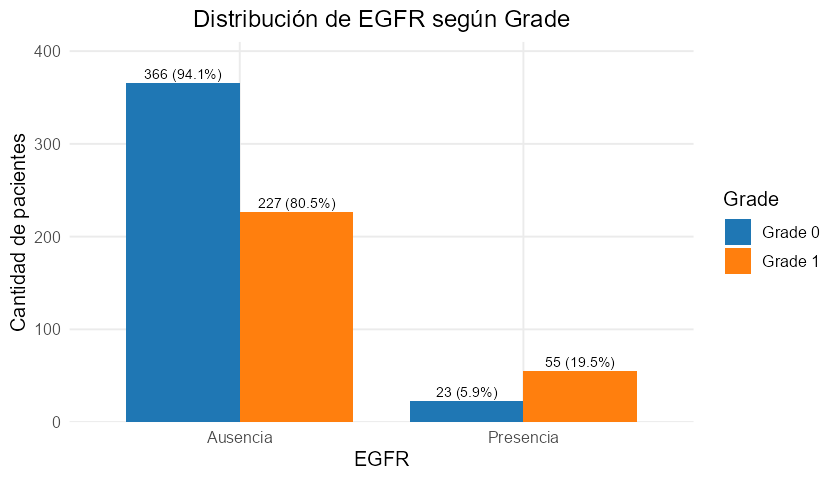

**CIC**

Para el caso del gen CIC, en el Grado 0, la ausencia de mutación es mayoritaria, con 300 pacientes (77,1%), mientras que 89 pacientes (22,9%) presentan la mutación. En el Grado 1, la ausencia de mutación aumenta considerablemente hasta 279 pacientes (98,9%), mientras que solamente 3 pacientes (1,1%) presentan una mutación en CIC. Por tanto, la presencia de la mutación en CIC es mucho más frecuente en el Grado 0. La proporción disminuye de 22,9% en el Grado 0 a apenas 1,1% en el Grado 1, lo que representa una diferencia de 21,8 puntos porcentuales. Este comportamiento resulta especialmente interesante para el análisis de clasificación, ya que la distribución de CIC cambia considerablemente entre las dos clases. En particular, la presencia de mutación en CIC parece estar asociada con el Grado 0, mientras que su ausencia está presente en prácticamente todos los pacientes de Grado 1. Esto sugiere que CIC podría ser una variable con un alto poder discriminativo para diferenciar ambas categorías.

**Prueba de independencia (Chi-cuadrado):** χ²(1) = 65.7626, p-value = 0.0000 → se rechaza H₀: existe asociación estadísticamente significativa (α = 0.05)

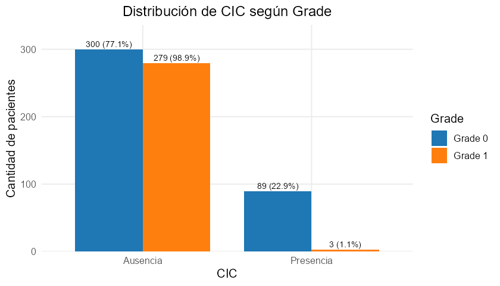

**MUC16**

La gráfica muestra la distribución de la mutación de MUC16 en los pacientes de Grado 0 y Grado 1. En ambos grupos predomina la ausencia de la mutación, aunque se observa una diferencia en la proporción de pacientes que presentan la alteración. En el Grado 0, la ausencia corresponde a 358 pacientes (92,0%), mientras que 31 pacientes (8,0%) presentan la mutación. En el Grado 1, la ausencia se presenta en 239 pacientes (84,8%), mientras que 43 pacientes (15,2%) presentan la mutación. Por tanto, la presencia de la mutación de MUC16 es más frecuente en el Grado 1. La proporción aumenta de 8,0% en el Grado 0 a 15,2% en el Grado 1, lo que representa una diferencia de 7,2 puntos porcentuales. A diferencia de variables como PTEN o CIC, la diferencia entre ambos grados en MUC16 es más moderada. Esto sugiere que MUC16 podría aportar cierta información para diferenciar las clases, pero su capacidad discriminativa individual parece menor a partir de esta distribución.

**Prueba de independencia (Chi-cuadrado):** χ²(1) = 8.8281, p-value = 0.0044 → se rechaza H₀: existe asociación estadísticamente significativa (α = 0.05)

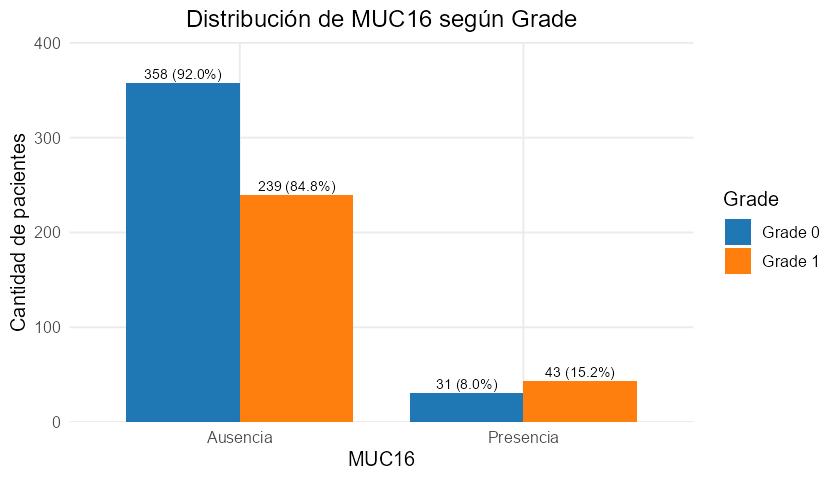

**PIK3CA**

La distribución de PIK3CA es bastante similar entre los dos grupos de Grade. La ausencia de la alteración es predominante tanto en Grade 0 (92,3 %) como en Grade 1 (90,4 %), mientras que su presencia representa únicamente el 7,7 % y 9,6 %, respectivamente. Aunque se observa una proporción ligeramente mayor de presencia de mutación de PIK3CA en Grade 1, la diferencia es pequeña (1,9 puntos porcentuales). Por lo tanto, a partir de esta comparación descriptiva, PIK3CA no presenta una diferencia marcada entre ambos grados.

**Prueba de independencia (Chi-cuadrado):** χ²(1) = 0.7295, p-value = 0.4753 → no se rechaza H₀: no hay evidencia de asociación significativa (α = 0.05)

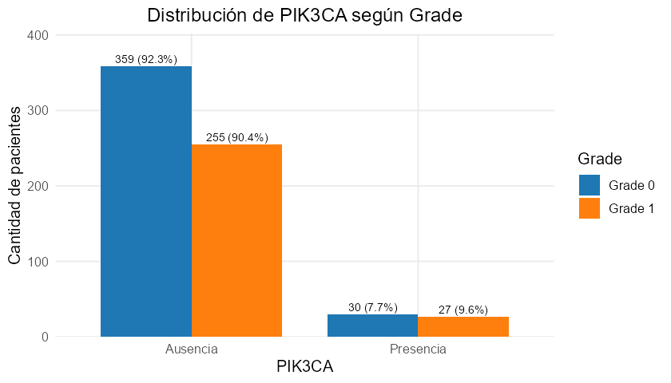

**NF1**

La distribución de mutación de NF1 presenta una ligera diferencia entre los grupos de Grade. La presencia de mutación de NF1 es mayor en Grade 1 (10,6 %) que en Grade 0 (6,7 %), mientras que la ausencia es predominante en ambos grupos. Esta diferencia de 3,9 puntos porcentuales sugiere una posible mayor frecuencia de alteraciones en NF1 en los pacientes de Grade 1. Sin embargo, debido a que la diferencia entre ambos grupos es relativamente pequeña y la ausencia de mutación de NF1 predomina ampliamente, no se observa una separación marcada entre los grados a partir de esta variable.

**Prueba de independencia (Chi-cuadrado):** χ²(1) = 3.3423, p-value = 0.0916 → no se rechaza H₀: no hay evidencia de asociación significativa (α = 0.05)

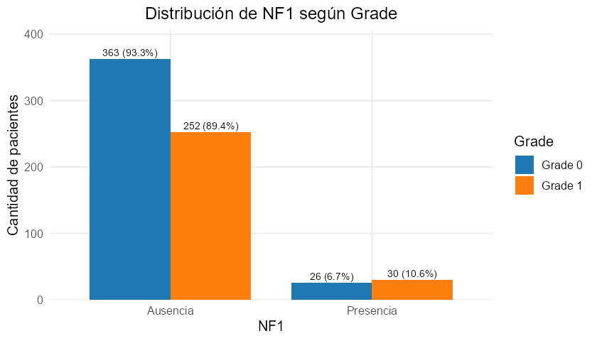

**PIK3R1**

La distribución de PIK3R1 muestra una diferencia entre los grupos de Grade. La presencia de esta alteración es mayor en Grade 1 (8,5 %) que en Grade 0 (3,9 %), con una diferencia de 4,6 puntos porcentuales. Sin embargo, la ausencia de alteración del gen PIK3R1 predomina claramente en ambos grupos, representando el 96,1 % de los casos en Grade 0 y el 91,5 % en Grade 1. Por lo tanto, aunque se observa una mayor frecuencia de presencia de PIK3R1 en Grade 1, la diferencia no es lo suficientemente marcada como para observar una separación clara entre los dos grupos únicamente mediante este análisis descriptivo.

**Prueba de independencia (Chi-cuadrado):** χ²(1) = 6.4700, p-value = 0.0175 → se rechaza H₀: existe asociación estadísticamente significativa (α = 0.05)

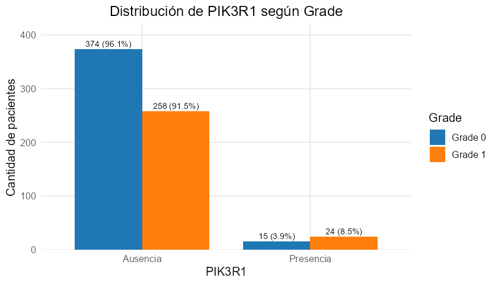

**FUBP1**

En términos descriptivos, FUBP1 presenta una distribución claramente diferente según el Grade. En Grade 0, la presencia de mutación de FUBP1 alcanza el 10,3 % de los pacientes, mientras que en Grade 1 esta proporción disminuye considerablemente hasta el 0,7 %. De manera consecuente, la ausencia de la variable es predominante en ambos grupos, aunque es especialmente alta en Grade 1, donde alcanza el 99,3 %. Esta diferencia de 9,6 puntos porcentuales en la presencia de FUBP1 sugiere que esta variable podría estar relacionada con la clasificación del grado tumoral y podría aportar información para diferenciar entre ambos grupos.

**Prueba de independencia (Chi-cuadrado):** χ²(1) = 25.5369, p-value = 0.0000 → se rechaza H₀: existe asociación estadísticamente significativa (α = 0.05)

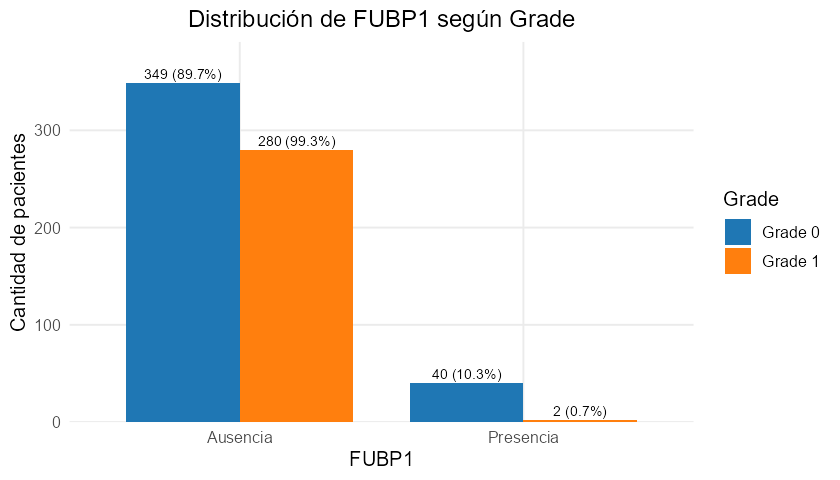

**RB1**

La gráfica muestra la distribución de RB1 entre los dos grupos de Grade y permite observar una diferencia apreciable en la frecuencia de esta variable. En Grade 0, la ausencia de mutación de RB1 representa el 98,5 % de los pacientes (383 casos), mientras que únicamente el 1,5 % presenta mutación de RB1 (6 casos). Por otro lado, en Grade 1, la ausencia corresponde al 90,4 % (255 casos), mientras que la presencia aumenta hasta el 9,6 % (27 casos). Por lo tanto, la presencia de mutación de RB1 es considerablemente más frecuente en Grade 1, donde alcanza el 9,6 %, frente al 1,5 % observado en Grade 0. Esto supone una diferencia de aproximadamente 8,1 puntos porcentuales. Aunque la ausencia continúa siendo la categoría predominante en ambos grupos, el aumento de la presencia de alteración del gen RB1 en Grade 1 genera una separación bastante visible entre las distribuciones.

**Prueba de independencia (Chi-cuadrado):** χ²(1) = 22.5548, p-value = 0.0000 → se rechaza H₀: existe asociación estadísticamente significativa (α = 0.05)

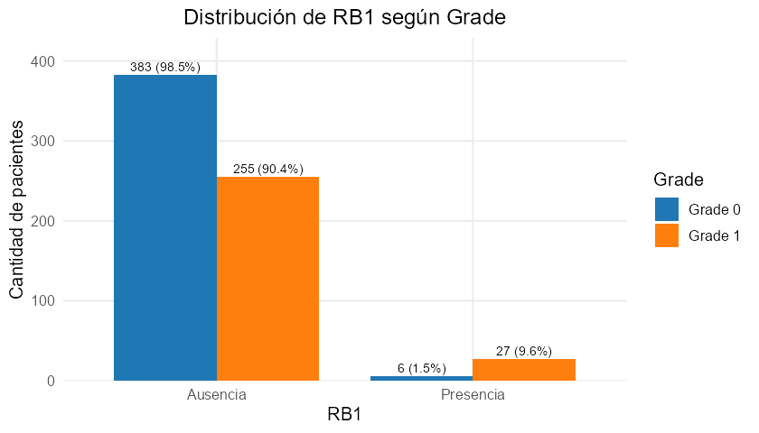

**NOTCH1**

En términos descriptivos, NOTCH1 presenta una distribución claramente diferenciada según el Grade. En Grade 0, el 8,5 % de los pacientes presenta mutación de NOTCH1, mientras que en Grade 1 no se observa ningún caso con presencia de esta variable. Por otro lado, la ausencia de alteración de NOTCH1 es predominante en ambos grupos, aunque alcanza el 100 % en Grade 1. Esta diferencia sugiere que la presencia de mutación de NOTCH1 podría estar relacionada con la clasificación del grado tumoral y podría ser una característica útil para distinguir entre ambos grupos.

**Prueba de independencia (Chi-cuadrado):** χ²(1) = 25.1603, p-value = 0.0000 → se rechaza H₀: existe asociación estadísticamente significativa (α = 0.05)

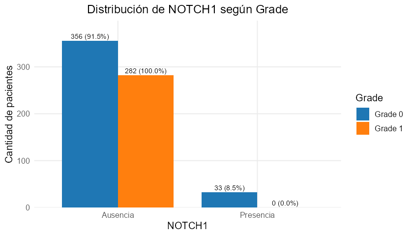

**BCOR**

La gráfica muestra la distribución de BCOR según el Grade y, a diferencia de algunas de las variables anteriores, presenta un comportamiento muy similar entre ambos grupos. En Grade 0, el 96,7 % de los pacientes presenta ausencia de mutación de BCOR (376 casos), mientras que el 3,3 % presenta su presencia (13 casos). En Grade 1, la ausencia corresponde al 96,8 % (273 casos) y la presencia al 3,2 % (9 casos). Las proporciones son prácticamente iguales entre los dos grados. La presencia de alteración del gen BCOR solo difiere en 0,1 puntos porcentuales, siendo ligeramente mayor en Grade 0 (3,3 %) que en Grade 1 (3,2 %). De manera similar, la ausencia presenta una diferencia mínima de 0,1 puntos porcentuales. Esto indica que no existe una separación visual relevante entre los grupos respecto a esta variable.

**Prueba de independencia (Chi-cuadrado):** χ²(1) = 0.0117, p-value = 1.0000 → no se rechaza H₀: no hay evidencia de asociación significativa (α = 0.05)

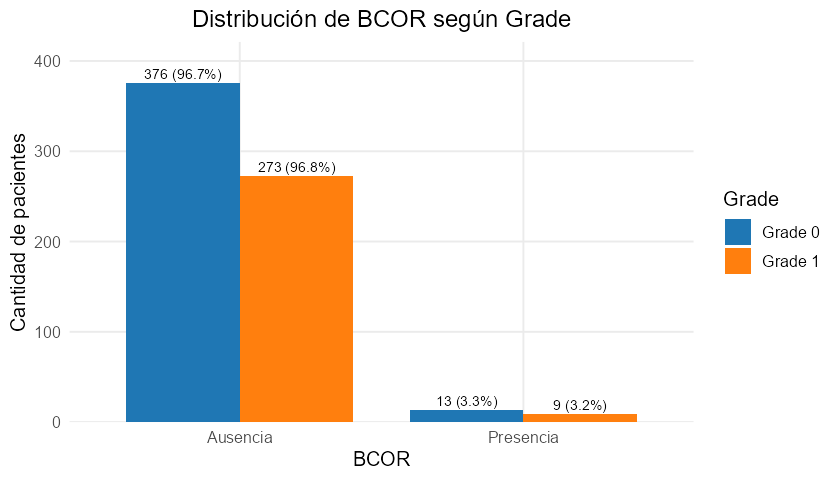

**CSMD3**

En términos descriptivos, CSMD3 presenta una distribución bastante similar entre los dos niveles de Grade. La presencia de esta variable es ligeramente mayor en Grade 1 (4,3 %) que en Grade 0 (2,8 %), mientras que la ausencia se mantiene como la categoría predominante, con 95,7 % y 97,2 %, respectivamente. Aunque este comportamiento muestra una pequeña diferencia entre los grupos, la magnitud de la variación es reducida, por lo que no se aprecia una separación marcada entre Grade 0 y Grade 1 a partir de CSMD3.

**Prueba de independencia (Chi-cuadrado):** χ²(1) = 1.0065, p-value = 0.4305 → no se rechaza H₀: no hay evidencia de asociación significativa (α = 0.05)

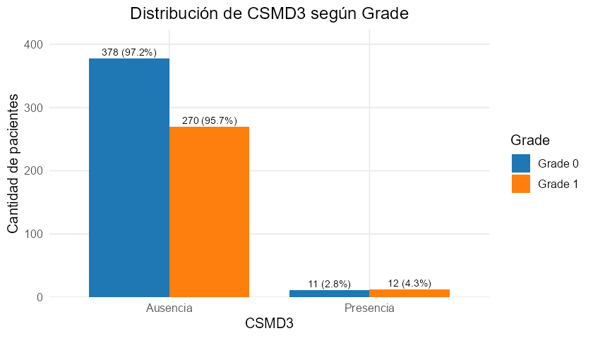

**SMARCA4**

La distribución de SMARCA4 muestra algunas diferencias entre los dos grupos de Grade. En Grade 0, la presencia de mutación de SMARCA4 se encuentra en el 4,9 % de los pacientes, mientras que en Grade 1 solamente alcanza el 1,4 %. Esto significa que la presencia de esta variable es aproximadamente 3,5 puntos porcentuales mayor en Grade 0. En ambos grupos, sin embargo, predomina ampliamente la ausencia de mutación de SMARCA4, especialmente en Grade 1, donde representa el 98,6 % de los casos. En consecuencia, aunque se observa una tendencia hacia una mayor presencia de mutación de SMARCA4 en Grade 0, la diferencia entre los grupos es moderada y no permite considerar por sí sola a esta variable como un diferenciador fuerte del grado tumoral.

**Prueba de independencia (Chi-cuadrado):** χ²(1) = 5.9326, p-value = 0.0264 → se rechaza H₀: existe asociación estadísticamente significativa (α = 0.05)

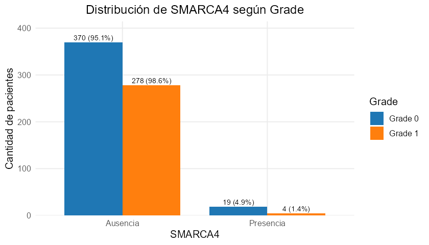

**GRIN2A**

La distribución de GRIN2A muestra que la ausencia de mutación es predominante tanto en los pacientes de Grade 0 como en los de Grade 1, con 98.7% y 95.0% de los casos, respectivamente. En contraste, la presencia de la mutación es poco frecuente en ambos grupos, aunque presenta una mayor proporción en Grade 1 (5.0%) frente a Grade 0 (1.3%), lo que representa una diferencia de 3.7 puntos porcentuales. Esta diferencia descriptiva indica una mayor frecuencia relativa de mutaciones en GRIN2A entre los pacientes de Grade 1; sin embargo, debido a la baja cantidad de casos con presencia de la mutación, no es suficiente para establecer por sí sola una asociación con el grado tumoral.

**Prueba de independencia (Chi-cuadrado):** χ²(1) = 8.0431, p-value = 0.0093 → se rechaza H₀: existe asociación estadísticamente significativa (α = 0.05)

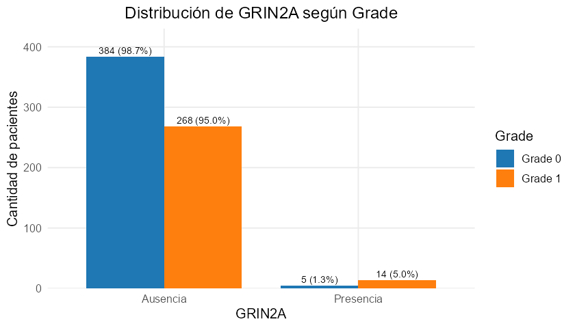

**IDH2**

La distribución de IDH2 muestra una diferencia bastante marcada entre los dos grupos de Grade. En Grade 0, la presencia de mutación de IDH2 corresponde al 4,9 % de los pacientes (19 casos), mientras que en Grade 1 solamente se presenta en el 0,7 % (2 casos). Por el contrario, la ausencia de esta variable es muy elevada en ambos grupos, aunque es ligeramente mayor en Grade 1, donde alcanza el 99,3 %, frente al 95,1 % observado en Grade 0. La diferencia en la presencia de IDH2 es de 4,2 puntos porcentuales, lo que indica que esta característica aparece con mayor frecuencia en Grade 0. Además, la distribución resulta especialmente interesante porque en Grade 1 prácticamente todos los pacientes presentan ausencia de alteración en el gen IDH2.

**Prueba de independencia (Chi-cuadrado):** χ²(1) = 9.3999, p-value = 0.0045 → se rechaza H₀: existe asociación estadísticamente significativa (α = 0.05)

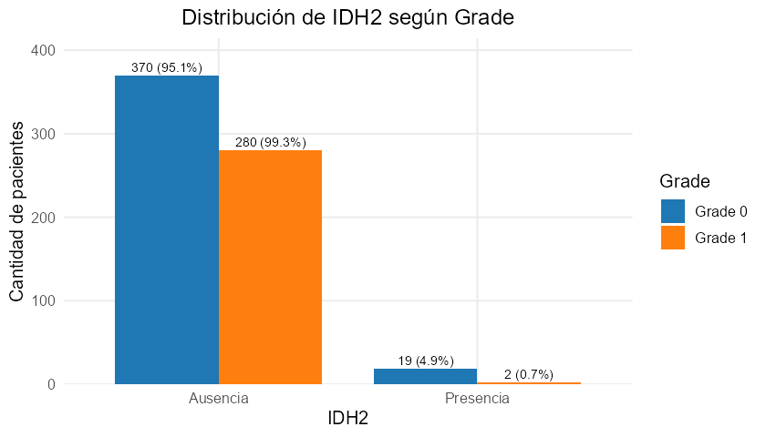

**FAT4**

En este caso, FAT4 presenta un comportamiento muy similar en los dos niveles de Grade. La presencia de esta variable representa el 2,3 % de los casos en Grade 0 y aumenta ligeramente hasta el 3,2 % en Grade 1, mientras que la ausencia se mantiene por encima del 96 % en ambos grupos. La diferencia de solo 0,9 puntos porcentuales indica que no existe una separación clara entre los grados a partir de esta variable. Por lo tanto, FAT4 parece presentar una capacidad discriminativa reducida por sí sola en este análisis bivariado.

**Prueba de independencia (Chi-cuadrado):** χ²(1) = 0.4826, p-value = 0.6508 → no se rechaza H₀: no hay evidencia de asociación significativa (α = 0.05)

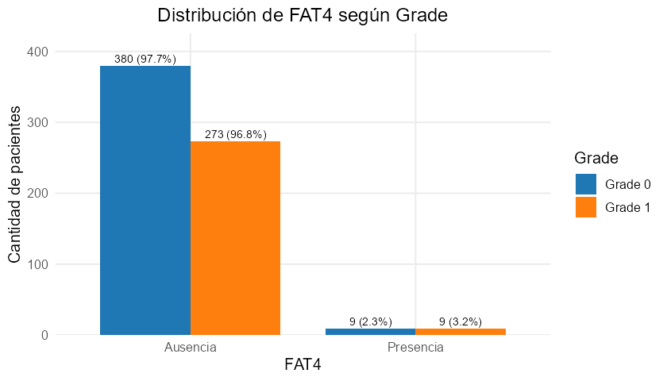

**PDGFRA**

La distribución de PDGFRA presenta una diferencia apreciable entre los dos grupos de Grade. En Grade 0, la presencia de mutación de PDGFRA corresponde al 1,5 % de los pacientes (6 casos), mientras que en Grade 1 aumenta hasta el 4,3 % (12 casos). Por otro lado, la ausencia de mutación de PDGFRA continúa siendo la categoría predominante en ambos grupos, con un 98,5 % en Grade 0 y un 95,7 % en Grade 1. Esto representa una diferencia de 2,8 puntos porcentuales en la presencia de mutación de PDGFRA entre ambos grados. Aunque la presencia de la variable sigue siendo poco frecuente, se observa una tendencia hacia una mayor proporción en Grade 1. Por tanto, a diferencia de variables como FAT4, donde las proporciones eran prácticamente iguales, PDGFRA muestra una separación algo más evidente entre los grupos.

**Prueba de independencia (Chi-cuadrado):** χ²(1) = 4.6090, p-value = 0.0568 → no se rechaza H₀: no hay evidencia de asociación significativa (α = 0.05)

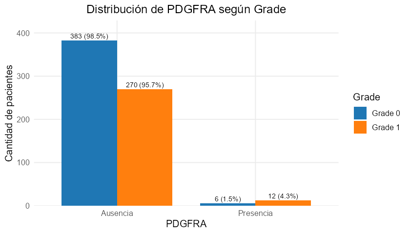

Las variables genéticas presentan, en conjunto, comportamientos muy heterogéneos frente a Grade: mientras genes como IDH1, CIC, ATRX y FUBP1 muestran diferencias marcadas y estadísticamente significativas entre LGG y GBM, otros como BCOR, CSMD3, FAT4 y PIK3CA presentan distribuciones prácticamente equivalentes entre ambos grupos, sugiriendo un poder discriminativo individual bajo.

### 1.5.5 Multicolinealidad y correlación

```r
train_data <- train_data |>
  mutate(Race_binary = factor(if_else(as.character(Race) == "0", 0, 1)))

cols_spearman <- setdiff(names(train_data), "Race")
spearman_corr <- train_data |>
  select(all_of(cols_spearman)) |>
  mutate(across(everything(), ~ as.numeric(as.character(.x)))) |>
  cor(method = "spearman")

# Solo el triángulo inferior (sin la diagonal), como la máscara del notebook
spearman_long <- as.data.frame(spearman_corr) |>
  rownames_to_column("var1") |>
  pivot_longer(-var1, names_to = "var2", values_to = "r") |>
  mutate(var1 = factor(var1, levels = rev(colnames(spearman_corr))),
         var2 = factor(var2, levels = colnames(spearman_corr))) |>
  filter(as.integer(var2) < match(var1, colnames(spearman_corr)))

ggplot(spearman_long, aes(x = var2, y = var1, fill = r)) +
  geom_tile(color = "white", linewidth = 0.5) +
  scale_fill_gradient2(low = "#2369BD", mid = "white", high = "#A9373B",
                       midpoint = 0, limits = c(-1, 1),
                       name = "Coeficiente de Correlación\nde Spearman (r)") +
  labs(title = sprintf("Matriz de Correlación de Spearman (Train Set - %d Variables)",
                       ncol(spearman_corr)),
       x = NULL, y = NULL) +
  theme(axis.text.x = element_text(angle = 90, vjust = 0.5, hjust = 1),
        panel.grid = element_blank())
```

[figure not shown]

```r
target_corr <- spearman_corr[, "Grade"]
target_corr <- sort(target_corr[names(target_corr) != "Grade"])

df_target_corr <- tibble(variable = names(target_corr), r = target_corr) |>
  mutate(variable = factor(variable, levels = variable),
         signo    = if_else(r < 0, "0", "1"))

ggplot(df_target_corr, aes(x = r, y = variable, fill = signo)) +
  geom_col(color = "black", linewidth = 0.3) +
  geom_vline(xintercept = 0, linetype = "dashed", linewidth = 0.4) +
  geom_text(aes(label = sprintf("%.2f", r), hjust = if_else(r >= 0, -0.15, 1.15)),
            size = 3, fontface = "bold") +
  scale_fill_manual(values = PALETTE_GRADE, guide = "none") +
  coord_cartesian(xlim = c(-0.85, 0.65)) +
  labs(title = "Correlación de Spearman de cada Atributo con la Severidad (Grade)",
       x = "Coeficiente de Correlación (r)", y = NULL) +
  theme(panel.grid.major.y = element_blank())
```

[figure not shown]

```r
phi_maximo <- function(tabla) {
  # Máximo |phi| alcanzable dadas las prevalencias marginales (solo 2x2).
  if (!all(dim(tabla) == c(2, 2))) return(NA_real_)
  n  <- sum(tabla)
  p1 <- sum(tabla[2, ]) / n
  p2 <- sum(tabla[, 2]) / n
  a  <- min(p1, p2); b <- max(p1, p2)
  if (a %in% c(0, 1) || b %in% c(0, 1)) return(NA_real_)
  sqrt((a * (1 - b)) / (b * (1 - a)))
}

phi_signado <- function(tabla) {
  # Coeficiente phi con signo (solo 2x2).
  if (!all(dim(tabla) == c(2, 2))) return(NA_real_)
  a <- tabla[1, 1]; b <- tabla[1, 2]; cc <- tabla[2, 1]; d <- tabla[2, 2]
  den <- sqrt(as.numeric(a + b) * (cc + d) * (a + cc) * (b + d))
  if (den > 0) (a * d - b * cc) / den else 0
}

calcular_asociacion <- function(x, y) {
  tabla <- table(x, y)

  chi2_c    <- suppressWarnings(chisq.test(tabla, correct = TRUE))
  chi2_s    <- suppressWarnings(chisq.test(tabla, correct = FALSE))
  esperadas <- chi2_c$expected

  supuesto_valido <- all(esperadas >= 5)
  freq_esp_min    <- min(esperadas)

  if (all(dim(tabla) == c(2, 2)) && !supuesto_valido) {
    p_val <- fisher.test(tabla)$p.value
    test  <- "Fisher exacto"
  } else {
    p_val <- chi2_c$p.value
    test  <- "Chi-cuadrado"
  }

  n    <- sum(tabla)
  phi2 <- unname(chi2_s$statistic) / n
  r <- nrow(tabla); k <- ncol(tabla)
  phi2corr <- max(0, phi2 - ((k - 1) * (r - 1)) / (n - 1))
  rcorr    <- r - ((r - 1)^2) / (n - 1)
  kcorr    <- k - ((k - 1)^2) / (n - 1)
  den      <- min(kcorr - 1, rcorr - 1)
  v_cramer <- if (den > 0) sqrt(phi2corr / den) else 0

  phi      <- phi_signado(tabla)
  pmax     <- phi_maximo(tabla)
  phi_norm <- if (!is.na(pmax) && pmax > 0) phi / pmax else NA_real_

  list(
    chi2 = unname(chi2_s$statistic), p_value = p_val, test = test,
    v_cramer = v_cramer, phi = phi, phi_max = pmax, phi_norm = phi_norm,
    supuesto_valido = supuesto_valido, freq_esp_min = freq_esp_min
  )
}


cat_cols <- setdiff(names(train_data), c("Age_at_diagnosis", "Race"))
n_cols   <- length(cat_cols)

cramer_matrix    <- matrix(1, nrow = n_cols, ncol = n_cols,
                           dimnames = list(cat_cols, cat_cols))
resultados_grade <- list()
resultados_pares <- list()

for (i in seq_len(n_cols)) {
  var1 <- cat_cols[i]
  for (j in seq_len(i - 1)) {
    var2 <- cat_cols[j]
    r <- calcular_asociacion(train_data[[var1]], train_data[[var2]])

    cramer_matrix[i, j] <- r$v_cramer
    cramer_matrix[j, i] <- r$v_cramer

    if ("Grade" %in% c(var1, var2)) {
      otra <- if (var1 == "Grade") var2 else var1
      resultados_grade[[length(resultados_grade) + 1]] <- tibble(
        Variable           = otra,
        Test               = r$test,
        `Chi2 (sin Yates)` = round(r$chi2, 2),
        `p-value`          = r$p_value,
        `V de Cramer`      = round(r$v_cramer, 4),
        `Supuesto OK`      = r$supuesto_valido,
        `Freq. esp. min`   = round(r$freq_esp_min, 2)
      )
    } else {
      resultados_pares[[length(resultados_pares) + 1]] <- tibble(
        `Variable 1`      = var1,
        `Variable 2`      = var2,
        Test              = r$test,
        `V de Cramer`     = round(r$v_cramer, 4),
        phi               = round(r$phi, 4),
        `phi max teórico` = round(r$phi_max, 4),
        `phi / phi max`   = round(r$phi_norm, 4),
        `p-value`         = r$p_value,
        `Supuesto OK`     = r$supuesto_valido,
        `Freq. esp. min`  = round(r$freq_esp_min, 2)
      )
    }
  }
}


df_asociacion <- bind_rows(resultados_grade) |>
  arrange(desc(`V de Cramer`))

# Corrección por contrastes múltiples (Benjamini-Hochberg).
# Se contrasta cada predictora contra el mismo objetivo, así que con 23 pruebas
# a alfa = 0,05 cabe esperar algún p-valor pequeño solo por azar. Se controla la
# tasa de falsos descubrimientos (FDR) y no la familiar: el objetivo aquí es
# cribar candidatas para un modelo posterior, y descartar una buena cuesta más
# que dejar pasar una dudosa, que el modelo ya filtrará. El q-valor es el
# p-valor ajustado: la proporción esperada de falsos positivos si se corta ahí.
#
# La familia son los 23 contrastes del cribado, así que entra también la edad,
# contrastada con Mann-Whitney por ser continua y no normal. Se corrige sobre
# las 23 y después se recupera la columna de las 22 categóricas.
p_edad <- wilcox.test(
  train_data$Age_at_diagnosis[train_data$Grade == 0],
  train_data$Age_at_diagnosis[train_data$Grade == 1],
  alternative = "two.sided", exact = FALSE
)$p.value

q_todas <- p.adjust(c(df_asociacion$`p-value`, p_edad), method = "BH")
df_asociacion$`q-value (BH)` <- head(q_todas, -1)
df_asociacion$`Sobrevive BH` <- df_asociacion$`q-value (BH)` < 0.05

cat(sprintf("Edad al diagnóstico (Mann-Whitney): p = %s, q = %s\n",
            signif(p_edad, 3), signif(tail(q_todas, 1), 3)))
```

```
## Edad al diagnóstico (Mann-Whitney): p = 2.33e-42, q = 2.68e-41
```

```r
df_pares <- bind_rows(resultados_pares)

# Resalta en amarillo las filas que no cumplen el supuesto de frecuencia
# esperada >= 5.
resaltar_supuesto <- function(kbl, supuesto_ok) {
  filas <- which(!supuesto_ok)
  if (length(filas) > 0) kbl <- kbl |> row_spec(filas, background = "#fff3cd")
  kbl
}

cat("ASOCIACIÓN CON GRADE (χ² / Fisher y V de Cramér)\n")
```

```
## ASOCIACIÓN CON GRADE (χ² / Fisher y V de Cramér)
```

```r
kable(df_asociacion |>
        mutate(`p-value`      = sprintf("%.6f", `p-value`),
               `q-value (BH)` = sprintf("%.6f", `q-value (BH)`)),
      row.names = FALSE) |>
  kable_styling(bootstrap_options = c("hover", "condensed"), full_width = TRUE) |>
  resaltar_supuesto(df_asociacion$`Supuesto OK`) |>
  scroll_box(width = "100%")
```

| Variable | Test | Chi2 (sin Yates) | p-value | V de Cramer | Supuesto OK | Freq. esp. min | q-value (BH) | Sobrevive BH |
| --- | --- | --- | --- | --- | --- | --- | --- | --- |
| IDH1 | Chi-cuadrado | 331.62 | 0.000000 | 0.7025 | TRUE | 135.33 | 0.000000 | TRUE |
| PTEN | Chi-cuadrado | 90.46 | 0.000000 | 0.3654 | TRUE | 47.49 | 0.000000 | TRUE |
| ATRX | Chi-cuadrado | 71.75 | 0.000000 | 0.3249 | TRUE | 72.29 | 0.000000 | TRUE |
| CIC | Chi-cuadrado | 65.76 | 0.000000 | 0.3109 | TRUE | 38.66 | 0.000000 | TRUE |
| EGFR | Chi-cuadrado | 29.39 | 0.000000 | 0.2059 | TRUE | 32.78 | 0.000000 | TRUE |
| FUBP1 | Chi-cuadrado | 25.54 | 0.000001 | 0.1914 | TRUE | 17.65 | 0.000003 | TRUE |
| NOTCH1 | Chi-cuadrado | 25.16 | 0.000001 | 0.1899 | TRUE | 13.87 | 0.000004 | TRUE |
| RB1 | Chi-cuadrado | 22.55 | 0.000005 | 0.1794 | TRUE | 13.87 | 0.000013 | TRUE |
| TP53 | Chi-cuadrado | 10.66 | 0.001446 | 0.1201 | TRUE | 113.47 | 0.003325 | TRUE |
| IDH2 | Chi-cuadrado | 9.40 | 0.004493 | 0.1120 | TRUE | 8.83 | 0.008531 | TRUE |
| MUC16 | Chi-cuadrado | 8.83 | 0.004422 | 0.1081 | TRUE | 31.10 | 0.008531 | TRUE |
| Race_binary | Chi-cuadrado | 8.74 | 0.004822 | 0.1074 | TRUE | 25.22 | 0.008531 | TRUE |
| GRIN2A | Chi-cuadrado | 8.04 | 0.009315 | 0.1025 | TRUE | 7.99 | 0.015302 | TRUE |
| PIK3R1 | Chi-cuadrado | 6.47 | 0.017479 | 0.0903 | TRUE | 16.39 | 0.026800 | TRUE |
| SMARCA4 | Chi-cuadrado | 5.93 | 0.026367 | 0.0858 | TRUE | 9.67 | 0.037903 | TRUE |
| PDGFRA | Chi-cuadrado | 4.61 | 0.056803 | 0.0734 | TRUE | 7.56 | 0.076851 | FALSE |
| NF1 | Chi-cuadrado | 3.34 | 0.091643 | 0.0591 | TRUE | 23.54 | 0.117100 | FALSE |
| Gender | Chi-cuadrado | 2.92 | 0.103271 | 0.0535 | TRUE | 114.73 | 0.125012 | FALSE |
| CSMD3 | Chi-cuadrado | 1.01 | 0.430521 | 0.0027 | TRUE | 9.67 | 0.495099 | FALSE |
| PIK3CA | Chi-cuadrado | 0.73 | 0.475326 | 0.0000 | TRUE | 23.96 | 0.520595 | FALSE |
| BCOR | Chi-cuadrado | 0.01 | 1.000000 | 0.0000 | TRUE | 9.25 | 1.000000 | FALSE |
| FAT4 | Chi-cuadrado | 0.48 | 0.650786 | 0.0000 | TRUE | 7.56 | 0.680367 | FALSE |

```r
UMBRAL_V <- 0.40

df_pares_asociados <- df_pares |>
  filter(`V de Cramer` > UMBRAL_V) |>
  arrange(desc(`V de Cramer`))

cat(sprintf("\nPARES DE PREDICTORES CON ALTA ASOCIACIÓN MUTUA (V > %.2f)\n", UMBRAL_V))
```

```
##
## PARES DE PREDICTORES CON ALTA ASOCIACIÓN MUTUA (V > 0.40)
```

```r
if (nrow(df_pares_asociados) == 0) {
  cat(sprintf("No se detectaron pares con V > %.2f.\n", UMBRAL_V))
} else {
  n_inval <- sum(!df_pares_asociados$`Supuesto OK`)
  if (n_inval > 0) {
    cat(sprintf("Atención: %d de estos pares NO cumplen el supuesto de frecuencia esperada ≥ 5 (resaltados en amarillo).\n",
                n_inval))
  }
}
```

```r
if (nrow(df_pares_asociados) > 0) {
  kable(df_pares_asociados |> mutate(`p-value` = sprintf("%.6f", `p-value`)),
        row.names = FALSE) |>
    kable_styling(bootstrap_options = c("hover", "condensed"), full_width = TRUE) |>
    resaltar_supuesto(df_pares_asociados$`Supuesto OK`) |>
    scroll_box(width = "100%")
}
```

| Variable 1 | Variable 2 | Test | V de Cramer | phi | phi max teórico | phi / phi max | p-value | Supuesto OK | Freq. esp. min |
| --- | --- | --- | --- | --- | --- | --- | --- | --- | --- |
| ATRX | TP53 | Chi-cuadrado | 0.5475 | 0.5484 | 0.7155 | 0.7665 | 0.000000 | TRUE | 69.21 |
| FUBP1 | CIC | Chi-cuadrado | 0.4681 | 0.4694 | 0.6483 | 0.7241 | 0.000000 | TRUE | 5.76 |
| ATRX | IDH1 | Chi-cuadrado | 0.4596 | 0.4609 | 0.6112 | 0.7541 | 0.000000 | TRUE | 82.54 |
| PTEN | IDH1 | Chi-cuadrado | 0.4068 | -0.4083 | 0.4685 | -0.8716 | 0.000000 | TRUE | 54.23 |

```r
UMBRAL_R    <- 0.70
UMBRAL_NORM <- 0.70

cat("DIAGNÓSTICO DE MULTICOLINEALIDAD ENTRE PREDICTORES\n")
```

```
## DIAGNÓSTICO DE MULTICOLINEALIDAD ENTRE PREDICTORES
```

```r
n_inval <- sum(!df_pares$`Supuesto OK`)
cat("\n0) Validez de los contrastes entre predictores\n")
```

```
##
## 0) Validez de los contrastes entre predictores
```

```r
cat(sprintf("   • Pares evaluados: %d\n", nrow(df_pares)))
```

```
##    • Pares evaluados: 231
```

```r
cat(sprintf("   • Pares con frecuencia esperada < 5: %d (%.1f%%) → resueltos con Fisher exacto\n",
            n_inval, n_inval / nrow(df_pares) * 100))
```

```
##    • Pares con frecuencia esperada < 5: 130 (56.3%) → resueltos con Fisher exacto
```

```r
pares_binarios <- df_pares |> filter(!is.na(`phi max teórico`))
alcanzables    <- sum(pares_binarios$`phi max teórico` >= UMBRAL_R)
total_bin      <- nrow(pares_binarios)

cat(sprintf("\n1) Viabilidad del umbral |r| > %.2f\n", UMBRAL_R))
```

```
##
## 1) Viabilidad del umbral |r| > 0.70
```

```r
cat(sprintf("   • Pares binarios evaluados: %d\n", total_bin))
```

```
##    • Pares binarios evaluados: 231
```

```r
cat(sprintf("   • Pares que PUEDEN alcanzar |phi| ≥ %.2f: %d (%.1f%%)\n",
            UMBRAL_R, alcanzables, alcanzables / total_bin * 100))
```

```
##    • Pares que PUEDEN alcanzar |phi| ≥ 0.70: 87 (37.7%)
```

```r
cat(sprintf("   • Pares donde es matemáticamente IMPOSIBLE: %d (%.1f%%)\n",
            total_bin - alcanzables, (total_bin - alcanzables) / total_bin * 100))
```

```
##    • Pares donde es matemáticamente IMPOSIBLE: 144 (62.3%)
```

```r
cat("   → Por desbalance de prevalencias, un umbral absoluto sobre |r| no es\n")
```

```
##    → Por desbalance de prevalencias, un umbral absoluto sobre |r| no es
```

```r
cat("     un criterio informativo para la mayoría de los pares.\n")
```

```
##      un criterio informativo para la mayoría de los pares.
```

```r
pares_altos <- list()
columnas    <- colnames(spearman_corr)
for (i in seq_along(columnas)) {
  for (j in seq_len(i - 1)) {
    r_val <- spearman_corr[i, j]
    if (abs(r_val) > UMBRAL_R) {
      pares_altos[[length(pares_altos) + 1]] <- tibble(
        `Variable 1` = columnas[i], `Variable 2` = columnas[j], r = round(r_val, 4)
      )
    }
  }
}

df_redundancias <- bind_rows(pares_altos)
df_predictores_red <- if (nrow(df_redundancias) > 0) {
  df_redundancias |> filter(`Variable 1` != "Grade", `Variable 2` != "Grade")
} else {
  df_redundancias
}

cat(sprintf("\n2) Criterio absoluto |r| > %.2f\n", UMBRAL_R))
```

```
##
## 2) Criterio absoluto |r| > 0.70
```

```r
if (nrow(df_predictores_red) == 0) {
  cat("   • Ningún par supera el umbral (resultado esperable, ver punto 1).\n")
} else {
  print(as.data.frame(df_predictores_red), row.names = FALSE)
}
```

```
##    • Ningún par supera el umbral (resultado esperable, ver punto 1).
```

```r
df_norm  <- df_pares |> filter(!is.na(`phi / phi max`))
red_norm <- df_norm |>
  filter(abs(`phi / phi max`) > UMBRAL_NORM) |>
  arrange(desc(abs(`phi / phi max`)))

cat(sprintf("\n3) Criterio normalizado |phi / phi_max| > %.2f\n", UMBRAL_NORM))
```

```
##
## 3) Criterio normalizado |phi / phi_max| > 0.70
```

```r
cat("   (corrige el techo impuesto por las prevalencias marginales)\n")
```

```
##    (corrige el techo impuesto por las prevalencias marginales)
```

```r
if (nrow(red_norm) == 0) {
  cat("   • No se detectaron pares con redundancia relativa alta.\n")
}
```

```r
if (nrow(red_norm) > 0) {
  kable(red_norm |>
          select(`Variable 1`, `Variable 2`, phi, `phi max teórico`,
                 `phi / phi max`, `V de Cramer`, `Supuesto OK`),
        row.names = FALSE) |>
    kable_styling(bootstrap_options = c("hover", "condensed"), full_width = FALSE) |>
    resaltar_supuesto(red_norm$`Supuesto OK`)
}
```

| Variable 1 | Variable 2 | phi | phi max teórico | phi / phi max | V de Cramer | Supuesto OK |
| --- | --- | --- | --- | --- | --- | --- |
| IDH2 | IDH1 | -0.1727 | 0.1871 | -0.9226 | 0.1684 | TRUE |
| EGFR | IDH1 | -0.3391 | 0.3776 | -0.8980 | 0.3371 | TRUE |
| PTEN | IDH1 | -0.4083 | 0.4685 | -0.8716 | 0.4068 | TRUE |
| RB1 | IDH1 | -0.2047 | 0.2368 | -0.8644 | 0.2011 | TRUE |
| NOTCH1 | IDH1 | 0.1954 | 0.2368 | 0.8252 | 0.1917 | TRUE |
| FUBP1 | IDH1 | 0.2198 | 0.2690 | 0.8169 | 0.2165 | TRUE |
| CIC | IDH1 | 0.3283 | 0.4150 | 0.7910 | 0.3262 | TRUE |
| ATRX | TP53 | 0.5484 | 0.7155 | 0.7665 | 0.5475 | TRUE |
| ATRX | IDH1 | 0.4609 | 0.6112 | 0.7541 | 0.4596 | TRUE |
| FUBP1 | CIC | 0.4694 | 0.6483 | 0.7241 | 0.4681 | TRUE |

```r
cat(sprintf("\n4) Criterio V de Cramér > %.2f: %d pares (ver celda anterior).\n",
            UMBRAL_V, nrow(df_pares_asociados)))
```

```
##
## 4) Criterio V de Cramér > 0.40: 4 pares (ver celda anterior).
```

#### 1.5.5.1 Multicolinealidad conjunta: factor de inflación de la varianza

Los criterios anteriores miran pares, y la multicolinealidad no es un fenómeno por pares: una variable puede ser casi reconstruible a partir de una combinación de varias sin parecerse a ninguna por separado. El factor de inflación de la varianza (VIF) responde a esa pregunta, porque regresa cada predictora contra todas las demás a la vez y mide cuánto se infla la varianza de su coeficiente por culpa de esa redundancia. Se interpreta con dos referencias habituales: por encima de 5 conviene vigilar, por encima de 10 el coeficiente deja de ser interpretable.

```r
# VIF de cada predictora: 1 / (1 - R2) de regresarla contra las otras 22.
predictoras <- setdiff(names(train_data), c("Grade", "Race"))
X_vif <- train_data |>
  select(all_of(predictoras)) |>
  mutate(across(everything(), ~ as.numeric(as.character(.x))))

df_vif <- map_dfr(predictoras, function(nombre) {
  modelo <- lm(reformulate(setdiff(predictoras, nombre), response = nombre), data = X_vif)
  r2 <- summary(modelo)$r.squared
  tibble(Variable = nombre,
         R2       = round(r2, 4),
         VIF      = round(if (r2 < 1) 1 / (1 - r2) else Inf, 2))
}) |>
  arrange(desc(VIF))

cat("FACTOR DE INFLACION DE LA VARIANZA (las 8 mas altas)\n")
```

```
## FACTOR DE INFLACION DE LA VARIANZA (las 8 mas altas)
```

```r
kable(head(df_vif, 8), row.names = FALSE) |>
  kable_styling(bootstrap_options = c("striped", "condensed"), full_width = FALSE)
```

| Variable | R2 | VIF |
| --- | --- | --- |
| IDH1 | 0.6769 | 3.09 |
| ATRX | 0.4697 | 1.89 |
| CIC | 0.4458 | 1.80 |
| Age_at_diagnosis | 0.4175 | 1.72 |
| TP53 | 0.4138 | 1.71 |
| FUBP1 | 0.2900 | 1.41 |
| PTEN | 0.2160 | 1.28 |
| IDH2 | 0.2067 | 1.26 |

```r
peor <- df_vif[1, ]
cat(sprintf("\nVIF maximo: %s en %s. Umbrales de referencia: 5 (vigilar) y 10 (grave).\n",
            peor$VIF, peor$Variable))
```

```
##
## VIF maximo: 3.09 en IDH1. Umbrales de referencia: 5 (vigilar) y 10 (grave).
```

El análisis bivariado y de correlación de Spearman sobre el conjunto de entrenamiento ($n = 671$) revela asociaciones clínico-moleculares relevantes entre los Gliomas de Bajo Grado (LGG) y el Glioblastoma Multiforme (GBM).

### 1.5.6 Asociaciones con la severidad tumoral (`Grade`)

**Asociaciones con LGG.** La mutación en `IDH1` presenta la mayor capacidad discriminativa en sentido inverso respecto a la severidad tumoral ($r = -0,70$, $V \approx 0,70$, $p < 0,001$). Le siguen `ATRX` ($r = -0,33$, $V \approx 0,32$) y `CIC` ($r = -0,31$, $V \approx 0,31$).

**Asociaciones con GBM.** `Age_at_diagnosis` constituye el principal correlato clínico directo con la severidad ($r = +0,53$), lo que refleja una mayor frecuencia de GBM en edades avanzadas. Entre las variables genéticas, `PTEN` presenta la asociación más fuerte ($V = 0,3654$, $r = +0,37$), seguido de `EGFR` ($V = 0,2059$, $r = +0,21$) y `RB1` ($V = 0,1794$, $r = +0,18$).

**Variables sin asociación significativa.** Las variables con $p > 0,05$ en la prueba de Chi-cuadrado, valores de $V < 0,08$ y magnitudes de $\lvert r \rvert < 0,10$, entre ellas `PDGFRA`, `NF1`, `Gender`, `CSMD3`, `BCOR`, `PIK3CA` y `FAT4`, presentan asociaciones débiles o insignificantes con `Grade`. Estos resultados respaldan su exclusión como variables prioritarias en la selección del conjunto de predictores.

### 1.5.7 Interacciones entre variables genéticas

Para las asociaciones entre mutaciones, se identificaron patrones de co-ocurrencia con valores de $V > 0,40$.

- **`ATRX`–`TP53`** presenta la mayor fuerza de asociación mutua ($V = 0,5475$).
- **`FUBP1`–`CIC`** muestra una asociación de $V = 0,4681$.
- **`ATRX`–`IDH1`** alcanza un valor de $V = 0,4596$.

Estas relaciones reflejan patrones de co-ocurrencia entre determinados marcadores genéticos dentro del conjunto analizado.

El factor de inflación de la varianza confirma por la vía conjunta lo que sugieren los pares: ninguna predictora es reconstruible a partir de las demás, con un VIF máximo de 3,09 en `IDH1`, muy por debajo del umbral de 5. El panel retenido puede entrar completo en un modelo sin que los coeficientes se vuelvan inestables.

Sobre los contrastes múltiples, la tabla de asociación incorpora el q-valor de Benjamini-Hochberg: las asociaciones que superan el umbral sin corregir lo siguen superando después de corregir, de modo que el panel de variables relevantes no depende de ese ajuste.

Por otra parte, la relación entre **`PTEN` e `IDH1`** ($V = 0,4068$) presenta un patrón de exclusión mutua, asociado a la distribución diferencial de estas alteraciones entre los grupos LGG y GBM.